# 05_Descriptives

Chiara Draxler

24 1 2022

# Introduction for working code:

0. Download the Code from Github. The new downloaded folder hc_switch_cccu-main contains the R project, Rmd Code, created data frames, knitted Html Code, Figures as .pdf and.jpg, Preregistered synthetic Code, and a folder to store the downloaded RData called RData.

Name the folder appropriately (when downloading the code from GitHub the folder will be hc_switch_cccu-main).

1. Download data from https://www.icpsr.umich.edu/web/DSDR/studies/37067/datadocumentation

Attention! The downloaded project from GitHub does not contain any data files!

–> Click on Download, then select R, then follow the login –> store data in the folder specific to the R project in an extra sub-folder called RData (i.e., hc_switch_cccu-main - > RData). If you downloaded the code from GitHub, the RData folder will be already in the hc_switch_cccu-main projects folder.

–> Within the RData folder store data for wave 1 in DS0001, for wave 2 in DS0002 and so on (i.e., hc_switch_cccu-main - > RData -> DS0001 ). If you downloaded the code from GitHub, the relevant folders will be already there.

–> name the Rdata files according to the wave:

Wave 1: 37067-0001-Data (i.e., hc_switch_cccu-main - > RData -> DS0001 -> 37067-0001-Data.rda )

Wave 2: 37067-0002-Data (i.e., hc_switch_cccu-main - > RData -> DS0002 -> 37067-0002-Data.rda )

Wave 3: 37067-0003-Data (i.e., hc_switch_cccu-main - > RData -> DS0003 -> 37067-0003-Data.rda )

Wave 4: 37067-0004-Data (i.e., hc_switch_cccu-main - > RData -> DS0004 -> 37067-0004-Data.rda )

–> attention to the .rda ending when loading the data into R!

2. make sure to install all relevant packages before running the code!

All relevant packages and versions can be seen in the section “Analyses”

3. run the code according to the defined order beginning with 01_ (or 0 if you want to have a look at the synthetic data) and ending with 09_ so that all data frames are created appropriately
4. Run the Code :)

# 1. load Data

```r
load("cccu_MA.RData")
load("cccu_excluded.RData")
```

# 2. Load Packages

```r
library(psych)
library(dplyr)
library(rstatix)
library(ufs)
library(Hmisc)
```

# 3. Participants

## filter values for waves

```r
cccu_MA_t1 <- cccu_MA%>%
  filter(WAVE == "t1")

cccu_MA_t2 <- cccu_MA%>%
  filter(WAVE == "t2")

cccu_MA_t3 <- cccu_MA%>%
  filter(WAVE == "t3")

cccu_MA_t4 <- cccu_MA%>%
  filter(WAVE == "t4")
```

## hormonal vs. non hormonal contraception

```r
table(cccu_MA_t1$hc)#IUD & non_hc should be zero bc of exclusion - yes
```

```
##
##         hc     non_hc IUD&non_hc
##       1032        691          0
```

```r
1032/1723
```

```
## [1] 0.5989553
```

```r
cccu_MA_t1_only_hc <- cccu_MA_t1 %>%
  filter(hc == "hc") %>%
  filter(CONDOMR != "(1) yes" | is.na(CONDOMR),
         VASECTOMY != "(1) yes" | is.na(VASECTOMY),
         WITHDRAWR != "(1) yes" | is.na(WITHDRAWR),
         NFPR != "(1) yes" | is.na(NFPR),
         SPERMR != "(1) yes" | is.na(SPERMR))

table(cccu_MA_t1_only_hc$PILL) # sum is 630 = hormonal users only
```

```
##
##  (0) No (1) Yes
##     137     493
```

```r
table(cccu_MA_t1_only_hc$PATCH)
```

```
##
##  (0) No (1) Yes
##     624       6
```

```r
table(cccu_MA_t1_only_hc$RING)
```

```
##
##  (0) No (1) Yes
##     585      45
```

```r
table(cccu_MA_t1_only_hc$DEPO)
```

```
##
##  (0) No (1) Yes
##     568      62
```

```r
table(cccu_MA_t1_only_hc$IMPLANT)
```

```
##
##  (0) No (1) Yes
##     601      29
```

```r
table(cccu_MA_t1_only_hc$IUD)
```

```
##
##  (0) No (1) Yes
##     627       3
```

```r
cccu_MA_t1_combi_hc <- cccu_MA_t1 %>%
  filter(hc == "hc") %>%
  filter(CONDOMR == "(1) yes" |
           VASECTOMY == "(1) yes" |
           WITHDRAWR == "(1) yes" |
           NFPR == "(1) yes" |
           SPERMR == "(1) yes")

table(cccu_MA_t1_combi_hc$PILL)
```

```
##
##  (0) No (1) Yes
##      65     337
```

```r
table(cccu_MA_t1_combi_hc$PATCH)
```

```
##
##  (0) No (1) Yes
##     398       4
```

```r
table(cccu_MA_t1_combi_hc$RING)
```

```
##
##  (0) No (1) Yes
##     371      31
```

```r
table(cccu_MA_t1_combi_hc$DEPO)
```

```
##
##  (0) No (1) Yes
##     371      31
```

```r
table(cccu_MA_t1_combi_hc$IMPLANT)
```

```
##
##  (0) No (1) Yes
##     394       8
```

```r
table(cccu_MA_t1_combi_hc$IUD)
```

```
##
##  (0) No (1) Yes
##     401       1
```

```r
cccu_MA_t1_non_hc <- cccu_MA_t1 %>%
  filter(hc == "non_hc")

table(cccu_MA_t1_non_hc$CONDOMR) # sum is n of non-hc users = 691
```

```
##
##  (0) no (1) yes
##     297     394
```

```r
table(cccu_MA_t1_non_hc$VASECTOMY)
```

```
##
##  (0) No (1) Yes
##     670       0
```

```r
table(cccu_MA_t1_non_hc$WITHDRAWR)
```

```
##
##  (0) no (1) yes
##     312     379
```

```r
table(cccu_MA_t1_non_hc$NFPR)
```

```
##
##  (0) no (1) yes
##     611      80
```

```r
table(cccu_MA_t1_non_hc$SPERMR)
```

```
##
##  (0) no (1) yes
##     662      29
```

```r
table(cccu_MA_t1_non_hc$NOBARRIER)
```

```
##
##  (0) No (1) Yes
##     670       0
```

## Age

```r
#as.numeric
psych::describe(cccu_MA_t1$AGE)
```

```
##    vars    n  mean   sd median trimmed  mad min max range skew kurtosis   se
## X1    1 1723 28.15 5.18     28   27.92 5.93  18  39    21 0.36    -0.73 0.12
```

```r
table(cccu_MA_t1$AGE)
```

```
##
##  18  19  20  21  22  23  24  25  26  27  28  29  30  31  32  33  34  35  36  37
##  10  27  42  68  78 118 129 154 117 113 139 123  79  73  54  71  68  57  59  43
##  38  39
##  54  47
```

## Ethnicity

```r
table(cccu_MA_t1$Ethnicity)
```

```
##
##    White, Non-Hispanic    Black, Non-Hispanic    Other, Non-Hispanic
##                   1169                    141                    138
##               Hispanic 2+ Races, Non-Hispanic
##                    275                      0
```

```r
1169/1723
```

```
## [1] 0.6784678
```

```r
275/1723
```

```
## [1] 0.1596053
```

## Degree

```r
table(cccu_MA_t1$DEGREE_recode)
```

```
##
##               no formal education                  1st to 4th grade
##                                 0                                 1
##                     5th/6th grade                     7th/8th grade
##                                 9                                 7
##                         9th grade                        10th grade
##                                13                                12
##                        11th grade           12th grade / no diploma
##                                 8                                15
## high school diploma or equivalent           some college, no degree
##                               205                               432
##                  associate degree                  bachelors degree
##                               186                               597
##                    masters degree   professional or doctoral degree
##                               197                                41
```

```r
597/1723
```

```
## [1] 0.3464887
```

```r
432/1723
```

```
## [1] 0.2507255
```

## Employment Status

```r
table(cccu_MA_t1$Employment_status)
```

```
##
##                 Working - as a paid employee
##                                         1078
##                      Working - self-employed
##                                           81
## Not working - on temporary layoff from a job
##                                           12
##               Not working - looking for work
##                                          186
##                        Not working - retired
##                                            0
##                       Not working - disabled
##                                           26
##                          Not working - other
##                                          340
```

```r
1078/1723
```

```
## [1] 0.6256529
```

```r
81/1723
```

```
## [1] 0.04701103
```

```r
(12+186+26+340)/1723
```

```
## [1] 0.327336
```

```r
12/564
```

```
## [1] 0.0212766
```

```r
186/564
```

```
## [1] 0.3297872
```

```r
26/564
```

```
## [1] 0.04609929
```

```r
340/564
```

```
## [1] 0.6028369
```

```r
12+186+26+340
```

```
## [1] 564
```

## Relationship Status & Duration

```r
#status
table(cccu_MA_t1$partnered)
```

```
##
##    0    1
##  430 1293
```

```r
1293/1723
```

```
## [1] 0.7504353
```

```r
table(cccu_MA_t1$rel_dur_factor)
```

```
##
##   Single   0q-25q  26q-50q  51q-75q 76q-100q
##      430      358      361      305      269
```

```r
#duration
table(cccu_MA_t1$rel_dur)
```

```
##
##   0   1   2   3   4   5   6   7   8   9  10  11  12  13  14  15  16  17  18  19
##   7   1   2   1   1   2   5   5   6  11   1   4   7  10   5   5   5   8  13   7
##  20  21  22  23  24  25  26  27  28  29  30  31  32  33  34  35  36  37  38  39
##   5   5   2   2  22  10   6   5   3   3  13   6   6   8   7   3  20  11  11   7
##  40  41  42  43  44  45  46  47  48  49  50  51  52  53  54  55  56  57  58  59
##  10   6   9   4   4   5   3  10  24  13   9  10  13   6  11   2   3   8   7  10
##  60  61  62  63  64  65  66  67  68  69  70  71  72  73  74  75  76  77  78  79
##  34  15   8   6  12   3  14   7   5  10   6  11  32   5   6   4   5   7   6   6
##  80  81  82  83  84  85  86  87  88  89  90  91  92  93  94  95  96  97  98  99
##   6   5   6   7  27   6   8   6   9   9  11   4   7   1   4  12  37   6   5   3
## 100 101 102 103 104 105 106 107 108 109 110 111 112 113 114 116 117 118 119 120
##   7   8   3   5   3   4   2   6  17   4   9   6   2   7  10   2   3   3   1  33
## 121 122 123 124 125 126 127 128 129 130 131 132 133 134 135 136 137 138 139 140
##   3   6   2   3   2   2   3   5   2   4   3  22   3   4   3   2   6   5   1   1
## 141 142 143 144 145 146 147 149 150 151 152 153 154 155 156 157 158 159 160 161
##   2   2   6  25   5   3   5   3   7   1   2   4   2   4  18   1   3   4   5   1
## 162 163 164 165 167 168 169 171 172 173 174 175 176 177 179 180 182 183 186 187
##   4   2   1   3   1  16   3   1   1   5   5   2   1   2   3  19   1   3   1   1
## 190 191 192 194 198 199 200 201 202 204 205 207 208 209 210 213 214 216 219 222
##   3   2   7   1   2   2   2   1   2   8   2   4   3   2   2   2   1   7   1   2
## 226 228 232 233 238 240 245 246 250 252 258 261 264 265 273 276 277 292 324 542
##   2   6   1   1   1   5   1   1   1   2   1   1   1   3   1   1   1   1   1   1
```

```r
psych::describe(cccu_MA_t1$rel_dur)
```

```
##    vars    n  mean    sd median trimmed   mad min max range skew kurtosis   se
## X1    1 1293 91.37 58.84     82   86.26 56.34   0 542   542 1.03     2.54 1.64
```

```r
describe(cccu_MA_t1$rel_dur_years)
```

```
## cccu_MA_t1$rel_dur_years
##        n  missing distinct     Info     Mean      Gmd      .05      .10
##     1293      430       27    0.995    87.42    65.18       12       24
##      .25      .50      .75      .90      .95
##       48       72      120      168      204
##
## lowest :   0  12  24  36  48, highest: 264 276 288 324 540
```

```r
describe(cccu_MA_t1$rel_dur_months)
```

```
## cccu_MA_t1$rel_dur_months
##        n  missing distinct     Info     Mean      Gmd      .05      .10
##     1293      430       12    0.968    3.948     4.18        0        0
##      .25      .50      .75      .90      .95
##        0        3        7       10       11
##
## Value       0.00  0.99  1.98  2.97  3.96  4.95  5.94  6.93  7.92  8.91  9.90
## Frequency    398   102    88    76    83    80   127    58    59    78    59
## Proportion 0.308 0.079 0.068 0.059 0.064 0.062 0.098 0.045 0.046 0.060 0.046
##
## Value      11.00
## Frequency     85
## Proportion 0.066
##
## For the frequency table, variable is rounded to the nearest 0.11
```

## Region and State

```r
#region
table(cccu_MA_t1$Region_recode)
```

```
##
## Northeast   Midwest     South      West
##       282       446       548       447
```

```r
548/1723
```

```
## [1] 0.3180499
```

```r
283/1723
```

```
## [1] 0.1642484
```

```r
#state
table(cccu_MA_t1$state_recode)
```

```
##
##          Maine  New Hampshire        Vermont  Massachusetts   Rhode Island
##              6              3              5             40              8
##     Conneticut       New York     New Jersey   Pennsylvania           Ohio
##             16             86             28             90             77
##        Indiana       Illinois       Michigan      Wisconsin      Minnesota
##             30             71             60             62             35
##           Iowa       Missouri   North Dakota   South Dakota         Nevada
##             29             43              2              4             32
##         Kansas       Delaware       Maryland           D.C.       Virginia
##             17              4             29              5             37
##  West Virginia North Carolina South Carolina        Georgia        Florida
##              9             56             16             51            100
##       Kentucky      Tennessee        Alabama    Mississippi       Arkansas
##             27             36             21             10             14
##      Louisiana       Oklahoma          Texas        Montana          Idaho
##             17             12            104              9             13
##        Wyoming       Colorado     New Mexico        Arizona           Utah
##              2             20             11             27             37
##     Washington         Oregon     California         Alaska         Hawaii
##             44             34            229              3              2
```

## Number of Kids

```r
table(cccu_MA_t1$NKIDS_t1)
```

```
##
##         0         1         2         3 4 or more
##       936       329       304        98        56
```

```r
936/1723
```

```
## [1] 0.5432385
```

```r
329/1723
```

```
## [1] 0.190946
```

```r
304/1723
```

```
## [1] 0.1764364
```

## Type of Insurance

```r
table(cccu_MA_t1$TYPEINS)
```

```
##
##                                                                                                                 (-1) Refused
##                                                                                                                            0
##                       (1) Private health insurance I get through my job or school, a family member or that I pay for myself.
##                                                                                                                         1201
##                              (2) (Medicaid Program - BASED ON PPSTATEN) or some other government-sponsored health insurance.
##                                                                                                                          236
##                                                                                      (3) Some other type of health insurance
##                                                                                                                           19
##                                                                                           (4) I don't have health insurance.
##                                                                                                                          267
##                                                       (2) {#\\.POV_Q38} or some other government-sponsored health insurance.
##                                                                                                                            0
## (0) Insurance obtained through a health insurance marketplace or exchange, such as www.healthcare.gov or {state-specific mar
##                                                                                                                            0
##                  (1) Private health insurance that I get through my job or school, a family member or that I pay for myself.
##                                                                                                                            0
##                                                           (2) {PPSTATE} or some other government-sponsored health insurance.
##                                                                                                                            0
##        (5) Insurance obtained through a health insurance marketplace or exchange, such as www.healthcare.gov{#POV_PROGNAME_Q
##                                                                                                                            0
```

```r
table(cccu_MA_t1$TYPEINS_recode)
```

```
##
##   No  Yes
##  267 1456
```

```r
1456/1723
```

```
## [1] 0.8450377
```

## Income

```r
table(cccu_MA_t1$Income)
```

```
##
##     Less than $5,000     $5,000 to $7,499     $7,500 to $9,999
##                   57                   38                   42
##   $10,000 to $12,499   $12,500 to $14,999   $15,000 to $19,999
##                   45                   51                   54
##   $20,000 to $24,999   $25,000 to $29,999   $30,000 to $34,999
##                   88                  121                  102
##   $35,000 to $39,999   $40,000 to $49,999   $50,000 to $59,999
##                  105                  195                  166
##   $60,000 to $74,999   $75,000 to $84,999   $85,000 to $99,999
##                  174                  112                  134
## $100,000 to $124,999 $125,000 to $149,999 $150,000 to $174,999
##                  106                   56                   37
##     $175,000 or more
##                   40
```

## POVRATE

```r
psych::describe(cccu_MA_t1$POVRATE)
```

```
##    vars    n  mean  sd median trimmed    mad min  max range skew kurtosis   se
## X1    1 1723 313.7 232    250  285.47 212.01  14 1455  1441 1.13     1.23 5.59
```

```r
table(cccu_MA_t1$POVRATE)
```

```
##
##   14   16   18   19   20   22   23   25   26   27   28   29   32   33   35   36
##    2    3    1    4    3   13    3    1   15    7    1    1    2   21    1    1
##   38   39   41   42   44   45   46   49   50   51   56   57   58   59   60   64
##   12    1    7    4    2   11   11    7    1    5    8    4   11   16   11    4
##   65   71   72   73   74   76   78   79   83   84   89   91   92   96   98  101
##    3    3   16    1   14   18    4    1   10    1    9    9   14    3   13    2
##  102  105  107  116  118  119  120  121  123  128  139  141  144  145  149  157
##    8    5    2   11   19   22   17    1    6    1   11   17   30    7   30    6
##  163  167  170  178  182  187  193  195  196  201  204  206  215  216  218  229
##   21   13   18    4   37    2    3   30   22   10   14    2   36    1    7    1
##  236  239  240  246  248  250  258  259  265  288  291  293  296  297  299  322
##   44   34    1   10   34   14    7    1    2   40    9   45    8   70    5    1
##  336  342  347  354  363  364  394  401  403  417  419  444  446  485  488  492
##   12    9   21   37    2   56    1   27   28    6   24    2   60   32   25   14
##  504  509  525  529  531  568  576  589  597  602  604  611  646  652  705  716
##    2    5    1   43    1    1    1   30    9    4    9   50    1    3   10    5
##  720  744  764  828  851  909  922 1007 1074 1163 1231 1455
##   18   36   14    8   10   18   11    3   10    8    1    1
```

```r
(2 +   3  +  1  +  4  +  3   +13 +   3 +   1 +  15  +  7 +   1 +   1  +  2+   21    +1    +1 +  12 +   1 +   7 + 4   + 2  + 11 +  11  +  7   + 1 +   5+    8  +  4 +  11  + 16  + 11 +   4  +  3 +   3 +  16 +   1  + 14   +18 + 4  +  1 +  10+    1  +  9  +  9  + 14 +   3+   13)/1723
```

```
## [1] 0.1816599
```

# Comparison included to excluded sample

```r
comp_inex = rbind(cccu_MA %>% mutate(exclude = "no"),
                     cccu_excluded %>% mutate(exclude = "yes"))
table(comp_inex$exclude)
```

```
##
##   no  yes
## 3787 6452
```

## hc use

```r
table(comp_inex$hc)
```

```
##
##         hc     non_hc IUD&non_hc
##       3965       5282        992
```

```r
table(is.na(comp_inex$hc))
```

```
##
## FALSE
## 10239
```

```r
comp_inex <- comp_inex %>%
  mutate(hc = as.factor(ifelse(is.na(NOBARRIER), as.character(hc),
                               ifelse(NOBARRIER == "(1) Yes" & hc == "non_hc",
                                "no_contra",
                                as.character(hc)))))

cccu_excluded <- cccu_excluded %>%
  mutate(hc = as.factor(ifelse(is.na(NOBARRIER), as.character(hc),
                               ifelse(NOBARRIER == "(1) Yes" & hc == "non_hc",
                                "no_contra",
                                as.character(hc)))))
table(comp_inex$hc)
```

```
##
##         hc IUD&non_hc  no_contra     non_hc
##       3965        992       1273       4009
```

```r
chisq.test(comp_inex$hc, comp_inex$exclude, correct=FALSE)
```

```
##
##  Pearson's Chi-squared test
##
## data:  comp_inex$hc and comp_inex$exclude
## X-squared = 2070.6, df = 3, p-value < 2.2e-16
```

```r
cramersV(comp_inex$hc,comp_inex$exclude)
```

```
## Cramér's V =  0.45
```

```r
confIntV(comp_inex$hc,comp_inex$exclude, conf.level = 0.95)
```

```
## Cramér's V 95% confidence interval (point estimate = .45):
## Bootstrapped: [.44; .46]
## Using Fisher's z: [.43; .47]
```

```r
table(cccu_MA$hc)
```

```
##
##         hc     non_hc IUD&non_hc
##       2294       1493          0
```

```r
round(table(cccu_MA$hc)/3787, 2)
```

```
##
##         hc     non_hc IUD&non_hc
##       0.61       0.39       0.00
```

```r
table(is.na(cccu_MA$hc))
```

```
##
## FALSE
##  3787
```

```r
table(is.na(cccu_MA$hc))/3787
```

```
##
## FALSE
##     1
```

```r
table(cccu_excluded$hc)
```

```
##
##         hc IUD&non_hc  no_contra     non_hc
##       1671        992       1273       2516
```

```r
round(table(cccu_excluded$hc)/6452, 2)
```

```
##
##         hc IUD&non_hc  no_contra     non_hc
##       0.26       0.15       0.20       0.39
```

```r
table(is.na(cccu_excluded$hc))
```

```
##
## FALSE
##  6452
```

```r
table(is.na(cccu_excluded$hc))/6452
```

```
##
## FALSE
##     1
```

## contraceptive satisfation

```r
t.test(comp_inex$contra_satis ~ comp_inex$exclude,
       alternative = 'two.sided',
       paired = FALSE,
       conf.level = .95)
```

```
##
##  Welch Two Sample t-test
##
## data:  comp_inex$contra_satis by comp_inex$exclude
## t = 3.5542, df = 5898.1, p-value = 0.000382
## alternative hypothesis: true difference in means between group no and group yes is not equal to 0
## 95 percent confidence interval:
##  0.02885466 0.09983367
## sample estimates:
##  mean in group no mean in group yes
##          3.486137          3.421793
```

```r
comp_inex %>% cohens_d(contra_satis ~ exclude, var.equal = TRUE, ci = TRUE)
```

```
## # A tibble: 1 × 9
##   .y.          group1 group2 effsize    n1    n2 conf.low conf.high magnitude
## * <chr>        <chr>  <chr>    <dbl> <int> <int>    <dbl>     <dbl> <ord>
## 1 contra_satis no     yes     0.0890  3787  2845     0.04      0.14 negligible
```

```r
psych::describe(cccu_MA$contra_satis)
```

```
##    vars    n mean  sd median trimmed mad min max range  skew kurtosis   se
## X1    1 3787 3.49 0.7      4    3.61   0   1   4     3 -1.37     1.74 0.01
```

```r
psych::describe(cccu_excluded$contra_satis)
```

```
##    vars    n mean   sd median trimmed mad min max range  skew kurtosis   se
## X1    1 2845 3.42 0.75      4    3.56   0   1   4     3 -1.24     1.13 0.01
```

## sexual frequency

```r
chisq.test(comp_inex$sex_freq, comp_inex$exclude, correct=FALSE)
```

```
##
##  Pearson's Chi-squared test
##
## data:  comp_inex$sex_freq and comp_inex$exclude
## X-squared = 704.64, df = 3, p-value < 2.2e-16
```

```r
cramersV(comp_inex$sex_freq,comp_inex$exclude)
```

```
## Cramér's V =  0.26
```

```r
confIntV(comp_inex$sex_freq,comp_inex$exclude, conf.level = 0.95)
```

```
## Cramér's V 95% confidence interval (point estimate = .26):
## Bootstrapped: [.25; .28]
## Using Fisher's z: [.24; .28]
```

```r
table(cccu_MA$sex_freq)
```

```
##
##   No sex or once        2-5 times       6-10 times 11 or more times
##              498             1659             1036              594
```

```r
round(table(cccu_MA$sex_freq)/3787, 2)
```

```
##
##   No sex or once        2-5 times       6-10 times 11 or more times
##             0.13             0.44             0.27             0.16
```

```r
table(is.na(cccu_MA$sex_freq))
```

```
##
## FALSE
##  3787
```

```r
table(is.na(cccu_MA$sex_freq))/3787
```

```
##
## FALSE
##     1
```

```r
table(cccu_excluded$sex_freq)
```

```
##
##   No sex or once        2-5 times       6-10 times 11 or more times
##             2374             1879             1238              835
```

```r
2374+1879+1238+835+126
```

```
## [1] 6452
```

```r
round(table(cccu_excluded$sex_freq)/6452, 2)
```

```
##
##   No sex or once        2-5 times       6-10 times 11 or more times
##             0.37             0.29             0.19             0.13
```

```r
table(is.na(cccu_excluded$sex_freq))
```

```
##
## FALSE  TRUE
##  6326   126
```

```r
table(is.na(cccu_excluded$sex_freq))/6452
```

```
##
##      FALSE       TRUE
## 0.98047117 0.01952883
```

## sexual satisfaction

```r
t.test(comp_inex$sexual_satisfaction ~ comp_inex$exclude,
       alternative = 'two.sided',
       paired = FALSE,
       conf.level = .95)
```

```
##
##  Welch Two Sample t-test
##
## data:  comp_inex$sexual_satisfaction by comp_inex$exclude
## t = 3.8567, df = 8506.2, p-value = 0.0001158
## alternative hypothesis: true difference in means between group no and group yes is not equal to 0
## 95 percent confidence interval:
##  0.05061631 0.15525475
## sample estimates:
##  mean in group no mean in group yes
##          5.016636          4.913700
```

```r
comp_inex %>% cohens_d(sexual_satisfaction ~ exclude, var.equal = TRUE, ci = TRUE)
```

```
## # A tibble: 1 × 9
##   .y.             group1 group2 effsize    n1    n2 conf.low conf.high magnitude
## * <chr>           <chr>  <chr>    <dbl> <int> <int>    <dbl>     <dbl> <ord>
## 1 sexual_satisfa… no     yes     0.0824  3787  4832     0.04      0.12 negligib…
```

```r
psych::describe(cccu_MA$sexual_satisfaction)
```

```
##    vars    n mean   sd median trimmed  mad min max range  skew kurtosis   se
## X1    1 3787 5.02 1.16      5    5.21 1.48   1   6     5 -1.22     1.15 0.02
```

```r
psych::describe(cccu_excluded$sexual_satisfaction)
```

```
##    vars    n mean   sd median trimmed  mad min max range  skew kurtosis   se
## X1    1 4832 4.91 1.32      5    5.14 1.48   1   6     5 -1.19     0.68 0.02
```

## Age

```r
t.test(comp_inex$AGE ~ comp_inex$exclude,
       alternative = 'two.sided',
       paired = FALSE,
       conf.level = .95)
```

```
##
##  Welch Two Sample t-test
##
## data:  comp_inex$AGE by comp_inex$exclude
## t = -4.4804, df = 8106.3, p-value = 7.553e-06
## alternative hypothesis: true difference in means between group no and group yes is not equal to 0
## 95 percent confidence interval:
##  -0.6939269 -0.2715239
## sample estimates:
##  mean in group no mean in group yes
##          28.15289          28.63562
```

```r
comp_inex %>% cohens_d(AGE ~ exclude, var.equal = TRUE, ci = TRUE)
```

```
## # A tibble: 1 × 9
##   .y.   group1 group2 effsize    n1    n2 conf.low conf.high magnitude
## * <chr> <chr>  <chr>    <dbl> <int> <int>    <dbl>     <dbl> <ord>
## 1 AGE   no     yes    -0.0911  3787  6452    -0.13     -0.05 negligible
```

```r
psych::describe(cccu_MA$AGE)
```

```
##    vars    n  mean   sd median trimmed  mad min max range skew kurtosis   se
## X1    1 3787 28.15 5.21     27   27.93 5.93  18  39    21 0.36    -0.77 0.08
```

```r
psych::describe(cccu_excluded$AGE)
```

```
##    vars    n  mean   sd median trimmed  mad min max range skew kurtosis   se
## X1    1 6452 28.64 5.35     28    28.5 5.93  18  39    21 0.22     -0.9 0.07
```

## Degree

```r
chisq.test(comp_inex$DEGREE_recode, comp_inex$exclude, correct=FALSE)
```

```
##
##  Pearson's Chi-squared test
##
## data:  comp_inex$DEGREE_recode and comp_inex$exclude
## X-squared = 140.48, df = 13, p-value < 2.2e-16
```

```r
cramersV(comp_inex$DEGREE_recode,comp_inex$exclude)
```

```
## Cramér's V =  0.12
```

```r
confIntV(comp_inex$DEGREE_recode,comp_inex$exclude, conf.level = 0.95)
```

```
## Cramér's V 95% confidence interval (point estimate = .12):
## Bootstrapped: [.1; .14]
## Using Fisher's z: [.1; .14]
```

```r
table(cccu_MA$DEGREE_recode)
```

```
##
##               no formal education                  1st to 4th grade
##                                 0                                 1
##                     5th/6th grade                     7th/8th grade
##                                19                                15
##                         9th grade                        10th grade
##                                20                                26
##                        11th grade           12th grade / no diploma
##                                21                                27
## high school diploma or equivalent           some college, no degree
##                               421                               924
##                  associate degree                  bachelors degree
##                               402                              1364
##                    masters degree   professional or doctoral degree
##                               442                               105
```

```r
round(table(cccu_MA$DEGREE_recode)/3787, 2)
```

```
##
##               no formal education                  1st to 4th grade
##                              0.00                              0.00
##                     5th/6th grade                     7th/8th grade
##                              0.01                              0.00
##                         9th grade                        10th grade
##                              0.01                              0.01
##                        11th grade           12th grade / no diploma
##                              0.01                              0.01
## high school diploma or equivalent           some college, no degree
##                              0.11                              0.24
##                  associate degree                  bachelors degree
##                              0.11                              0.36
##                    masters degree   professional or doctoral degree
##                              0.12                              0.03
```

```r
table(is.na(cccu_MA$DEGREE_recode))
```

```
##
## FALSE
##  3787
```

```r
table(is.na(cccu_MA$DEGREE_recode))/3787
```

```
##
## FALSE
##     1
```

```r
table(cccu_excluded$DEGREE_recode)
```

```
##
##               no formal education                  1st to 4th grade
##                                 9                                 5
##                     5th/6th grade                     7th/8th grade
##                                34                                33
##                         9th grade                        10th grade
##                                57                                65
##                        11th grade           12th grade / no diploma
##                                67                                94
## high school diploma or equivalent           some college, no degree
##                              1048                              1710
##                  associate degree                  bachelors degree
##                               721                              1775
##                    masters degree   professional or doctoral degree
##                               669                               165
```

```r
round(table(cccu_excluded$DEGREE_recode)/6452, 2)
```

```
##
##               no formal education                  1st to 4th grade
##                              0.00                              0.00
##                     5th/6th grade                     7th/8th grade
##                              0.01                              0.01
##                         9th grade                        10th grade
##                              0.01                              0.01
##                        11th grade           12th grade / no diploma
##                              0.01                              0.01
## high school diploma or equivalent           some college, no degree
##                              0.16                              0.27
##                  associate degree                  bachelors degree
##                              0.11                              0.28
##                    masters degree   professional or doctoral degree
##                              0.10                              0.03
```

```r
table(is.na(cccu_excluded$DEGREE_recode))
```

```
##
## FALSE
##  6452
```

```r
table(is.na(cccu_excluded$DEGREE_recode))/6452
```

```
##
## FALSE
##     1
```

## Poverty

```r
t.test(comp_inex$POVRATE ~ comp_inex$exclude,
       alternative = 'two.sided',
       paired = FALSE,
       conf.level = .95)
```

```
##
##  Welch Two Sample t-test
##
## data:  comp_inex$POVRATE by comp_inex$exclude
## t = 10.515, df = 7620.7, p-value < 2.2e-16
## alternative hypothesis: true difference in means between group no and group yes is not equal to 0
## 95 percent confidence interval:
##  39.88961 58.17005
## sample estimates:
##  mean in group no mean in group yes
##          320.1458          271.1159
```

```r
comp_inex %>% cohens_d(POVRATE ~ exclude, var.equal = TRUE, ci = TRUE)
```

```
## # A tibble: 1 × 9
##   .y.     group1 group2 effsize    n1    n2 conf.low conf.high magnitude
## * <chr>   <chr>  <chr>    <dbl> <int> <int>    <dbl>     <dbl> <ord>
## 1 POVRATE no     yes      0.218  3787  6452     0.18      0.26 small
```

```r
psych::describe(cccu_MA$POVRATE)
```

```
##    vars    n   mean     sd median trimmed    mad min  max range skew kurtosis
## X1    1 3787 320.15 231.82    282  292.29 213.49  14 1532  1518 1.11     1.17
##      se
## X1 3.77
```

```r
psych::describe(cccu_excluded$POVRATE)
```

```
##    vars    n   mean     sd median trimmed    mad min  max range skew kurtosis
## X1    1 6452 271.12 220.72    215  239.84 186.81  13 1576  1563 1.52     3.12
##      se
## X1 2.75
```

## Health problems

```r
chisq.test(comp_inex$HLTHPROB_recode, comp_inex$exclude, correct=FALSE)
```

```
##
##  Pearson's Chi-squared test
##
## data:  comp_inex$HLTHPROB_recode and comp_inex$exclude
## X-squared = 5.6935, df = 1, p-value = 0.01703
```

```r
cramersV(comp_inex$HLTHPROB_recode,comp_inex$exclude)
```

```
## Cramér's V =  0.024
```

```r
confIntV(comp_inex$HLTHPROB_recode,comp_inex$exclude, conf.level = 0.95)
```

```
## Cramér's V 95% confidence interval (point estimate = .02):
## Bootstrapped: [.01; .04]
## Using Fisher's z: [0; .04]
```

```r
table(cccu_MA$HLTHPROB_recode)
```

```
##
##   No  Yes
## 3125  662
```

```r
round(table(cccu_MA$HLTHPROB_recode)/3787, 2)
```

```
##
##   No  Yes
## 0.83 0.17
```

```r
table(is.na(cccu_MA$HLTHPROB_recode))
```

```
##
## FALSE
##  3787
```

```r
table(is.na(cccu_MA$HLTHPROB_recode))/3787
```

```
##
## FALSE
##     1
```

```r
table(cccu_excluded$HLTHPROB_recode)
```

```
##
##   No  Yes
## 4735 1141
```

```r
round(table(cccu_excluded$HLTHPROB_recode)/6452, 2)
```

```
##
##   No  Yes
## 0.73 0.18
```

```r
table(is.na(cccu_excluded$HLTHPROB_recode))
```

```
##
## FALSE  TRUE
##  5876   576
```

```r
table(is.na(cccu_excluded$HLTHPROB_recode))/6452
```

```
##
##      FALSE       TRUE
## 0.91072536 0.08927464
```

## medical problems

```r
chisq.test(comp_inex$MEDPROB_recode, comp_inex$exclude, correct=FALSE)
```

```
##
##  Pearson's Chi-squared test
##
## data:  comp_inex$MEDPROB_recode and comp_inex$exclude
## X-squared = 0.71801, df = 1, p-value = 0.3968
```

```r
cramersV(comp_inex$MEDPROB_recode,comp_inex$exclude)
```

```
## Cramér's V =  0.0084
```

```r
confIntV(comp_inex$MEDPROB_recode,comp_inex$exclude, conf.level = 0.95)
```

```
## Cramér's V 95% confidence interval (point estimate = .01):
## Bootstrapped: [0; .03]
## Using Fisher's z: [0; .03]
```

```r
table(cccu_MA$MEDPROB_recode)
```

```
##
##   No  Yes
## 3444  343
```

```r
round(table(cccu_MA$MEDPROB_recode)/3787, 2)
```

```
##
##   No  Yes
## 0.91 0.09
```

```r
table(is.na(cccu_MA$MEDPROB_recode))
```

```
##
## FALSE
##  3787
```

```r
table(is.na(cccu_MA$MEDPROB_recode))/3787
```

```
##
## FALSE
##     1
```

```r
table(cccu_excluded$MEDPROB_recode)
```

```
##
##   No  Yes
## 5835  617
```

```r
round(table(cccu_excluded$MEDPROB_recode)/6452, 2)
```

```
##
##  No Yes
## 0.9 0.1
```

```r
table(is.na(cccu_excluded$MEDPROB_recode))
```

```
##
## FALSE
##  6452
```

```r
table(is.na(cccu_excluded$MEDPROB_recode))/6452
```

```
##
## FALSE
##     1
```

## gaps in insurance

```r
chisq.test(comp_inex$GAPINS_recode, comp_inex$exclude, correct=FALSE)
```

```
##
##  Pearson's Chi-squared test
##
## data:  comp_inex$GAPINS_recode and comp_inex$exclude
## X-squared = 43.399, df = 1, p-value = 4.465e-11
```

```r
cramersV(comp_inex$GAPINS_recode,comp_inex$exclude)
```

```
## Cramér's V =  0.065
```

```r
confIntV(comp_inex$GAPINS_recode,comp_inex$exclude, conf.level = 0.95)
```

```
## Cramér's V 95% confidence interval (point estimate = .07):
## Bootstrapped: [.05; .08]
## Using Fisher's z: [.05; .08]
```

```r
table(cccu_MA$GAPINS_recode)
```

```
##
##   No  Yes
## 3076  711
```

```r
round(table(cccu_MA$GAPINS_recode)/3787, 2)
```

```
##
##   No  Yes
## 0.81 0.19
```

```r
table(is.na(cccu_MA$GAPINS_recode))
```

```
##
## FALSE
##  3787
```

```r
table(is.na(cccu_MA$GAPINS_recode))/3787
```

```
##
## FALSE
##     1
```

```r
table(cccu_excluded$GAPINS_recode)
```

```
##
##   No  Yes
## 4811 1553
```

```r
round(table(cccu_excluded$GAPINS_recode)/6452, 2)
```

```
##
##   No  Yes
## 0.75 0.24
```

```r
table(is.na(cccu_excluded$MEDPROB_recode))
```

```
##
## FALSE
##  6452
```

```r
table(is.na(cccu_excluded$MEDPROB_recode))/6452
```

```
##
## FALSE
##     1
```

## insuranced?

```r
chisq.test(comp_inex$TYPEINS_recode, comp_inex$exclude, correct=FALSE)
```

```
##
##  Pearson's Chi-squared test
##
## data:  comp_inex$TYPEINS_recode and comp_inex$exclude
## X-squared = 32.883, df = 1, p-value = 9.788e-09
```

```r
cramersV(comp_inex$TYPEINS_recode,comp_inex$exclude)
```

```
## Cramér's V =  0.057
```

```r
confIntV(comp_inex$TYPEINS_recode,comp_inex$exclude, conf.level = 0.95)
```

```
## Cramér's V 95% confidence interval (point estimate = .06):
## Bootstrapped: [.04; .08]
## Using Fisher's z: [.04; .08]
```

```r
table(cccu_MA$TYPEINS_recode)
```

```
##
##   No  Yes
##  569 3218
```

```r
round(table(cccu_MA$TYPEINS_recode)/3787, 2)
```

```
##
##   No  Yes
## 0.15 0.85
```

```r
table(is.na(cccu_MA$TYPEINS_recode))
```

```
##
## FALSE
##  3787
```

```r
table(is.na(cccu_MA$TYPEINS_recode))/3787
```

```
##
## FALSE
##     1
```

```r
table(cccu_excluded$TYPEINS_recode)
```

```
##
##   No  Yes
## 1243 5121
```

```r
round(table(cccu_excluded$TYPEINS_recode)/6452, 2)
```

```
##
##   No  Yes
## 0.19 0.79
```

```r
table(is.na(cccu_excluded$TYPEINS_recode))
```

```
##
## FALSE  TRUE
##  6364    88
```

```r
table(is.na(cccu_excluded$TYPEINS_recode))/6452
```

```
##
##      FALSE       TRUE
## 0.98636082 0.01363918
```

## number of kids at t1

```r
chisq.test(comp_inex$NKIDS_t1, comp_inex$exclude, correct=FALSE)
```

```
##
##  Pearson's Chi-squared test
##
## data:  comp_inex$NKIDS_t1 and comp_inex$exclude
## X-squared = 54.247, df = 4, p-value = 4.671e-11
```

```r
cramersV(comp_inex$NKIDS_t1,comp_inex$exclude)
```

```
## Cramér's V =  0.073
```

```r
confIntV(comp_inex$NKIDS_t1,comp_inex$exclude, conf.level = 0.95)
```

```
## Cramér's V 95% confidence interval (point estimate = .07):
## Bootstrapped: [.06; .09]
## Using Fisher's z: [.05; .09]
```

```r
table(cccu_MA$NKIDS_t1)
```

```
##
##         0         1         2         3 4 or more
##      2121       704       631       216       115
```

```r
round(table(cccu_MA$NKIDS_t1)/3787, 2)
```

```
##
##         0         1         2         3 4 or more
##      0.56      0.19      0.17      0.06      0.03
```

```r
table(is.na(cccu_MA$NKIDS_t1))
```

```
##
## FALSE
##  3787
```

```r
table(is.na(cccu_MA$NKIDS_t1))/3787
```

```
##
## FALSE
##     1
```

```r
table(cccu_excluded$NKIDS_t1)
```

```
##
##         0         1         2         3 4 or more
##      3135      1366      1190       502       230
```

```r
round(table(cccu_excluded$NKIDS_t1)/6452, 2)
```

```
##
##         0         1         2         3 4 or more
##      0.49      0.21      0.18      0.08      0.04
```

```r
table(is.na(cccu_excluded$NKIDS_t1))
```

```
##
## FALSE  TRUE
##  6423    29
```

```r
table(is.na(cccu_excluded$NKIDS_t1))/6452
```

```
##
##      FALSE       TRUE
## 0.99550527 0.00449473
```

## pregnant between waves

```r
chisq.test(comp_inex$pregnant_between_waves, comp_inex$exclude, correct=FALSE)
```

```
##
##  Pearson's Chi-squared test
##
## data:  comp_inex$pregnant_between_waves and comp_inex$exclude
## X-squared = 141.32, df = 1, p-value < 2.2e-16
```

```r
cramersV(comp_inex$pregnant_between_waves,comp_inex$exclude)
```

```
## Cramér's V =  0.12
```

```r
confIntV(comp_inex$pregnant_between_waves,comp_inex$exclude, conf.level = 0.95)
```

```
## Cramér's V 95% confidence interval (point estimate = .12):
## Bootstrapped: [.1; .13]
## Using Fisher's z: [.1; .14]
```

```r
table(cccu_MA$pregnant_between_waves)
```

```
##
##   No  Yes
## 3655  132
```

```r
round(table(cccu_MA$pregnant_between_waves)/3787, 2)
```

```
##
##   No  Yes
## 0.97 0.03
```

```r
table(is.na(cccu_MA$pregnant_between_waves))
```

```
##
## FALSE
##  3787
```

```r
table(is.na(cccu_MA$pregnant_between_waves))/3787
```

```
##
## FALSE
##     1
```

```r
table(cccu_excluded$pregnant_between_waves)
```

```
##
##   No  Yes
## 5780  636
```

```r
round(table(cccu_excluded$pregnant_between_waves)/6452, 2)
```

```
##
##  No Yes
## 0.9 0.1
```

```r
table(is.na(cccu_excluded$pregnant_between_waves))
```

```
##
## FALSE  TRUE
##  6416    36
```

```r
table(is.na(cccu_excluded$pregnant_between_waves))/6452
```

```
##
##       FALSE        TRUE
## 0.994420335 0.005579665
```

## had baby between waves

```r
chisq.test(comp_inex$had_baby_between_waves, comp_inex$exclude, correct=FALSE)
```

```
##
##  Pearson's Chi-squared test
##
## data:  comp_inex$had_baby_between_waves and comp_inex$exclude
## X-squared = 12.235, df = 1, p-value = 0.000469
```

```r
cramersV(comp_inex$had_baby_between_waves,comp_inex$exclude)
```

```
## Cramér's V =  0.035
```

```r
confIntV(comp_inex$had_baby_between_waves,comp_inex$exclude, conf.level = 0.95)
```

```
## Cramér's V 95% confidence interval (point estimate = .03):
## Bootstrapped: [.02; .05]
## Using Fisher's z: [.02; .05]
```

```r
table(cccu_MA$had_baby_between_waves)
```

```
##
##   No  Yes
## 3697   90
```

```r
round(table(cccu_MA$had_baby_between_waves)/3787, 2)
```

```
##
##   No  Yes
## 0.98 0.02
```

```r
table(is.na(cccu_MA$had_baby_between_waves))
```

```
##
## FALSE
##  3787
```

```r
table(is.na(cccu_MA$had_baby_between_waves))/3787
```

```
##
## FALSE
##     1
```

```r
table(cccu_excluded$had_baby_between_waves)
```

```
##
##   No  Yes
## 6183  233
```

```r
round(table(cccu_excluded$had_baby_between_waves)/6452, 2)
```

```
##
##   No  Yes
## 0.96 0.04
```

```r
table(is.na(cccu_excluded$had_baby_between_waves))
```

```
##
## FALSE  TRUE
##  6416    36
```

```r
table(is.na(cccu_excluded$had_baby_between_waves))/6452
```

```
##
##       FALSE        TRUE
## 0.994420335 0.005579665
```

## avoidance

```r
t.test(comp_inex$Avoid_r ~ comp_inex$exclude,
       alternative = 'two.sided',
       paired = FALSE,
       conf.level = .95)
```

```
##
##  Welch Two Sample t-test
##
## data:  comp_inex$Avoid_r by comp_inex$exclude
## t = 10.295, df = 9259.7, p-value < 2.2e-16
## alternative hypothesis: true difference in means between group no and group yes is not equal to 0
## 95 percent confidence interval:
##  0.2950963 0.4339027
## sample estimates:
##  mean in group no mean in group yes
##          4.777396          4.412897
```

```r
comp_inex %>% cohens_d(Avoid_r ~ exclude, var.equal = TRUE, ci = TRUE)
```

```
## # A tibble: 1 × 9
##   .y.     group1 group2 effsize    n1    n2 conf.low conf.high magnitude
## * <chr>   <chr>  <chr>    <dbl> <int> <int>    <dbl>     <dbl> <ord>
## 1 Avoid_r no     yes      0.203  3787  6079     0.16      0.24 small
```

```r
psych::describe(cccu_MA$Avoid_r)
```

```
##    vars    n mean   sd median trimmed  mad min max range  skew kurtosis   se
## X1    1 3787 4.78 1.55      5    5.06 1.48   1   6     5 -1.13     0.16 0.03
```

```r
psych::describe(cccu_excluded$Avoid_r)
```

```
##    vars    n mean   sd median trimmed  mad min max range  skew kurtosis   se
## X1    1 6079 4.41 1.94      5    4.64 1.48   1   6     5 -0.81    -0.94 0.02
```

## feelings about pregnancy

```r
t.test(comp_inex$FEELPG_recode ~ comp_inex$exclude,
       alternative = 'two.sided',
       paired = FALSE,
       conf.level = .95)
```

```
##
##  Welch Two Sample t-test
##
## data:  comp_inex$FEELPG_recode by comp_inex$exclude
## t = -2.3085, df = 8564.7, p-value = 0.021
## alternative hypothesis: true difference in means between group no and group yes is not equal to 0
## 95 percent confidence interval:
##  -0.15483799 -0.01263154
## sample estimates:
##  mean in group no mean in group yes
##          3.405070          3.488805
```

```r
comp_inex %>% cohens_d(FEELPG_recode ~ exclude, var.equal = TRUE, ci = TRUE)
```

```
## # A tibble: 1 × 9
##   .y.           group1 group2 effsize    n1    n2 conf.low conf.high magnitude
## * <chr>         <chr>  <chr>    <dbl> <int> <int>    <dbl>     <dbl> <ord>
## 1 FEELPG_recode no     yes    -0.0468  3787  6074    -0.09   -0.0083 negligible
```

```r
psych::describe(cccu_MA$FEELPG_recode)
```

```
##    vars    n mean   sd median trimmed  mad min max range skew kurtosis   se
## X1    1 3787 3.41 1.69      3    3.38 1.48   1   6     5    0    -1.21 0.03
```

```r
psych::describe(cccu_excluded$FEELPG_recode)
```

```
##    vars    n mean   sd median trimmed  mad min max range  skew kurtosis   se
## X1    1 6074 3.49 1.85      4    3.49 2.97   1   6     5 -0.01    -1.39 0.02
```

## relationship duration

```r
chisq.test(comp_inex$rel_dur_factor, comp_inex$exclude, correct=FALSE)
```

```
##
##  Pearson's Chi-squared test
##
## data:  comp_inex$rel_dur_factor and comp_inex$exclude
## X-squared = 218.89, df = 4, p-value < 2.2e-16
```

```r
cramersV(comp_inex$rel_dur_factor,comp_inex$exclude)
```

```
## Cramér's V =  0.15
```

```r
confIntV(comp_inex$rel_dur_factor,comp_inex$exclude, conf.level = 0.95)
```

```
## Cramér's V 95% confidence interval (point estimate = .15):
## Bootstrapped: [.13; .17]
## Using Fisher's z: [.13; .17]
```

```r
table(cccu_MA$rel_dur_factor)
```

```
##
##   Single   0q-25q  26q-50q  51q-75q 76q-100q
##      932      792      760      684      619
```

```r
round(table(cccu_MA$rel_dur_factor)/3787, 2)
```

```
##
##   Single   0q-25q  26q-50q  51q-75q 76q-100q
##     0.25     0.21     0.20     0.18     0.16
```

```r
table(is.na(cccu_MA$rel_dur_factor))
```

```
##
## FALSE
##  3787
```

```r
table(is.na(cccu_MA$rel_dur_factor))/3787
```

```
##
## FALSE
##     1
```

```r
table(cccu_excluded$rel_dur_factor)
```

```
##
##   Single   0q-25q  26q-50q  51q-75q 76q-100q
##     2454      962      982     1045     1009
```

```r
round(table(cccu_excluded$rel_dur_factor)/6452, 2)
```

```
##
##   Single   0q-25q  26q-50q  51q-75q 76q-100q
##     0.38     0.15     0.15     0.16     0.16
```

```r
table(is.na(cccu_excluded$rel_dur_factor))
```

```
##
## FALSE
##  6452
```

```r
table(is.na(cccu_excluded$rel_dur_factor))/6452
```

```
##
## FALSE
##     1
```

# 4. Descriptives of Variables

## t1

```r
cccu_MA_t1_descriptives <- cccu_MA_t1 %>%
  select(
    hc, switch, contra_satis, hc_dur,
    sexual_satisfaction, sex_freq,
    AGE, DEGREE_recode, POVRATE,
    HLTHPROB_recode, MEDPROB_recode,
    GAPINS_recode, TYPEINS_recode,
    NKIDS_t1, pregnant_between_waves,
    had_baby_between_waves,
    Avoid_r, FEELPG_recode,
    rel_dur_factor)

psych::describe(cccu_MA_t1_descriptives$contra_satis)
```

```
##    vars    n mean   sd median trimmed mad min max range  skew kurtosis   se
## X1    1 1723 3.44 0.73      4    3.58   0   1   4     3 -1.29     1.44 0.02
```

```r
psych::describe(cccu_MA_t1_descriptives$hc_dur)
```

```
##    vars    n mean   sd median trimmed  mad min max range skew kurtosis   se
## X1    1 1032 6.97 4.64      6    6.52 4.45   0  40    40 1.26     3.74 0.14
```

```r
psych::describe(cccu_MA_t1_descriptives$sexual_satisfaction)
```

```
##    vars    n mean   sd median trimmed  mad min max range  skew kurtosis   se
## X1    1 1723 5.04 1.17      5    5.24 1.48   1   6     5 -1.24     1.12 0.03
```

```r
psych::describe(cccu_MA_t1_descriptives$AGE)
```

```
##    vars    n  mean   sd median trimmed  mad min max range skew kurtosis   se
## X1    1 1723 28.15 5.18     28   27.92 5.93  18  39    21 0.36    -0.73 0.12
```

```r
psych::describe(cccu_MA_t1_descriptives$POVRATE)
```

```
##    vars    n  mean  sd median trimmed    mad min  max range skew kurtosis   se
## X1    1 1723 313.7 232    250  285.47 212.01  14 1455  1441 1.13     1.23 5.59
```

```r
psych::describe(cccu_MA_t1_descriptives$Avoid_r)
```

```
##    vars    n mean   sd median trimmed mad min max range  skew kurtosis   se
## X1    1 1723 4.81 1.52      6    5.08   0   1   6     5 -1.14     0.23 0.04
```

```r
psych::describe(cccu_MA_t1_descriptives$FEELPG_recode)
```

```
##    vars    n mean   sd median trimmed  mad min max range skew kurtosis   se
## X1    1 1723 3.41 1.67      3    3.38 1.48   1   6     5    0    -1.18 0.04
```

```r
table(cccu_MA_t1_descriptives$hc)
```

```
##
##         hc     non_hc IUD&non_hc
##       1032        691          0
```

```r
table(cccu_MA_t1_descriptives$switch)
```

```
##
##    0    1
## 1483  240
```

```r
table(cccu_MA_t1_descriptives$sex_freq)
```

```
##
##   No sex or once        2-5 times       6-10 times 11 or more times
##              222              760              466              275
```

```r
table(cccu_MA_t1_descriptives$DEGREE_recode)
```

```
##
##               no formal education                  1st to 4th grade
##                                 0                                 1
##                     5th/6th grade                     7th/8th grade
##                                 9                                 7
##                         9th grade                        10th grade
##                                13                                12
##                        11th grade           12th grade / no diploma
##                                 8                                15
## high school diploma or equivalent           some college, no degree
##                               205                               432
##                  associate degree                  bachelors degree
##                               186                               597
##                    masters degree   professional or doctoral degree
##                               197                                41
```

```r
table(cccu_MA_t1_descriptives$HLTHPROB_recode)
```

```
##
##   No  Yes
## 1424  299
```

```r
table(cccu_MA_t1_descriptives$MEDPROB_recode)
```

```
##
##   No  Yes
## 1579  144
```

```r
table(cccu_MA_t1_descriptives$GAPINS_recode)
```

```
##
##   No  Yes
## 1382  341
```

```r
table(cccu_MA_t1_descriptives$TYPEINS_recode)
```

```
##
##   No  Yes
##  267 1456
```

```r
table(cccu_MA_t1_descriptives$NKIDS_t1)
```

```
##
##         0         1         2         3 4 or more
##       936       329       304        98        56
```

```r
table(cccu_MA_t1_descriptives$pregnant_between_waves)
```

```
##
##   No  Yes
## 1688   35
```

```r
table(cccu_MA_t1_descriptives$had_baby_between_waves)
```

```
##
##   No  Yes
## 1688   35
```

```r
table(cccu_MA_t1_descriptives$rel_dur_factor)
```

```
##
##   Single   0q-25q  26q-50q  51q-75q 76q-100q
##      430      358      361      305      269
```

## t2

```r
cccu_MA_t2_descriptives <- cccu_MA_t2 %>%
  select(
    hc, switch, contra_satis, hc_dur,
    sexual_satisfaction, sex_freq,
    AGE, DEGREE_recode, POVRATE,
    HLTHPROB_recode, MEDPROB_recode,
    GAPINS_recode, TYPEINS_recode,
    NKIDS_t1, pregnant_between_waves,
    had_baby_between_waves,
    Avoid_r, FEELPG_recode,
    rel_dur_factor)
colnames(cccu_MA_t2_descriptives)
```

```
##  [1] "hc"                     "switch"                 "contra_satis"
##  [4] "hc_dur"                 "sexual_satisfaction"    "sex_freq"
##  [7] "AGE"                    "DEGREE_recode"          "POVRATE"
## [10] "HLTHPROB_recode"        "MEDPROB_recode"         "GAPINS_recode"
## [13] "TYPEINS_recode"         "NKIDS_t1"               "pregnant_between_waves"
## [16] "had_baby_between_waves" "Avoid_r"                "FEELPG_recode"
## [19] "rel_dur_factor"
```

```r
psych::describe(cccu_MA_t2_descriptives$contra_satis)
```

```
##    vars    n mean   sd median trimmed mad min max range  skew kurtosis   se
## X1    1 1181  3.5 0.69      4    3.62   0   1   4     3 -1.37     1.75 0.02
```

```r
psych::describe(cccu_MA_t2_descriptives$hc_dur)
```

```
##    vars   n  mean  sd median trimmed  mad min max range skew kurtosis   se
## X1    1 717 12.19 5.2     12   12.08 4.45   0  35    35 0.39      0.9 0.19
```

```r
psych::describe(cccu_MA_t2_descriptives$sexual_satisfaction)
```

```
##    vars    n mean   sd median trimmed  mad min max range  skew kurtosis   se
## X1    1 1181 5.01 1.12      5    5.19 1.48   1   6     5 -1.14     1.02 0.03
```

```r
psych::describe(cccu_MA_t2_descriptives$AGE)
```

```
##    vars    n  mean   sd median trimmed  mad min max range skew kurtosis   se
## X1    1 1181 28.15 5.22     27   27.93 5.93  18  39    21 0.36    -0.78 0.15
```

```r
psych::describe(cccu_MA_t2_descriptives$POVRATE)
```

```
##    vars    n   mean     sd median trimmed    mad min  max range skew kurtosis
## X1    1 1181 323.36 227.49    282  296.57 213.49  14 1197  1183 1.06     0.94
##      se
## X1 6.62
```

```r
psych::describe(cccu_MA_t2_descriptives$Avoid_r)
```

```
##    vars    n mean   sd median trimmed  mad min max range  skew kurtosis   se
## X1    1 1181 4.76 1.57      5    5.04 1.48   1   6     5 -1.13     0.14 0.05
```

```r
psych::describe(cccu_MA_t2_descriptives$FEELPG_recode)
```

```
##    vars    n mean   sd median trimmed  mad min max range  skew kurtosis   se
## X1    1 1181 3.42 1.69      4     3.4 1.48   1   6     5 -0.02    -1.23 0.05
```

```r
table(cccu_MA_t2_descriptives$hc)
```

```
##
##         hc     non_hc IUD&non_hc
##        720        461          0
```

```r
table(cccu_MA_t2_descriptives$switch)
```

```
##
##    0    1
## 1033  148
```

```r
table(cccu_MA_t2_descriptives$sex_freq)
```

```
##
##   No sex or once        2-5 times       6-10 times 11 or more times
##              160              505              324              192
```

```r
table(cccu_MA_t2_descriptives$DEGREE_recode)
```

```
##
##               no formal education                  1st to 4th grade
##                                 0                                 0
##                     5th/6th grade                     7th/8th grade
##                                 5                                 4
##                         9th grade                        10th grade
##                                 4                                 7
##                        11th grade           12th grade / no diploma
##                                 8                                 7
## high school diploma or equivalent           some college, no degree
##                               128                               285
##                  associate degree                  bachelors degree
##                               130                               433
##                    masters degree   professional or doctoral degree
##                               135                                35
```

```r
table(cccu_MA_t2_descriptives$HLTHPROB_recode)
```

```
##
##  No Yes
## 973 208
```

```r
table(cccu_MA_t2_descriptives$MEDPROB_recode)
```

```
##
##   No  Yes
## 1064  117
```

```r
table(cccu_MA_t2_descriptives$GAPINS_recode)
```

```
##
##  No Yes
## 974 207
```

```r
table(cccu_MA_t2_descriptives$TYPEINS_recode)
```

```
##
##   No  Yes
##  171 1010
```

```r
table(cccu_MA_t2_descriptives$NKIDS_t1)
```

```
##
##         0         1         2         3 4 or more
##       664       225       192        65        35
```

```r
table(cccu_MA_t2_descriptives$pregnant_between_waves)
```

```
##
##   No  Yes
## 1135   46
```

```r
table(cccu_MA_t2_descriptives$had_baby_between_waves)
```

```
##
##   No  Yes
## 1157   24
```

```r
table(cccu_MA_t2_descriptives$rel_dur_factor)
```

```
##
##   Single   0q-25q  26q-50q  51q-75q 76q-100q
##      289      247      224      221      200
```

## t3

```r
cccu_MA_t3_descriptives <- cccu_MA_t3 %>%
  select(
    hc, switch, contra_satis, hc_dur,
    sexual_satisfaction, sex_freq,
    AGE, DEGREE_recode, POVRATE,
    HLTHPROB_recode, MEDPROB_recode,
    GAPINS_recode, TYPEINS_recode,
    NKIDS_t1, pregnant_between_waves,
    had_baby_between_waves,
    Avoid_r, FEELPG_recode,
    rel_dur_factor)

psych::describe(cccu_MA_t3_descriptives$contra_satis)
```

```
##    vars   n mean   sd median trimmed mad min max range  skew kurtosis   se
## X1    1 883 3.55 0.66      4    3.66   0   1   4     3 -1.51     2.36 0.02
```

```r
psych::describe(cccu_MA_t3_descriptives$hc_dur)
```

```
##    vars   n  mean   sd median trimmed  mad min max range skew kurtosis   se
## X1    1 536 17.13 6.79     18   17.54 5.93   0  41    41 -0.4     0.73 0.29
```

```r
psych::describe(cccu_MA_t3_descriptives$sexual_satisfaction)
```

```
##    vars   n mean   sd median trimmed  mad min max range  skew kurtosis   se
## X1    1 883 4.98 1.19      5    5.18 1.48   1   6     5 -1.26     1.26 0.04
```

```r
psych::describe(cccu_MA_t3_descriptives$AGE)
```

```
##    vars   n  mean   sd median trimmed  mad min max range skew kurtosis   se
## X1    1 883 28.16 5.25     27   27.95 5.93  18  39    21 0.36    -0.84 0.18
```

```r
psych::describe(cccu_MA_t3_descriptives$POVRATE)
```

```
##    vars   n   mean     sd median trimmed    mad min  max range skew kurtosis
## X1    1 883 328.43 237.05    282  300.34 226.84  14 1532  1518 1.12     1.28
##      se
## X1 7.98
```

```r
psych::describe(cccu_MA_t3_descriptives$Avoid_r)
```

```
##    vars   n mean   sd median trimmed  mad min max range skew kurtosis   se
## X1    1 883 4.74 1.58      5    5.01 1.48   1   6     5 -1.1     0.02 0.05
```

```r
psych::describe(cccu_MA_t3_descriptives$FEELPG_recode)
```

```
##    vars   n mean   sd median trimmed  mad min max range skew kurtosis   se
## X1    1 883 3.39 1.72      3    3.36 2.97   1   6     5 0.01    -1.26 0.06
```

```r
table(cccu_MA_t3_descriptives$hc)
```

```
##
##         hc     non_hc IUD&non_hc
##        542        341          0
```

```r
table(cccu_MA_t3_descriptives$switch)
```

```
##
##   0   1
## 786  97
```

```r
table(cccu_MA_t3_descriptives$sex_freq)
```

```
##
##   No sex or once        2-5 times       6-10 times 11 or more times
##              116              394              246              127
```

```r
table(cccu_MA_t3_descriptives$DEGREE_recode)
```

```
##
##               no formal education                  1st to 4th grade
##                                 0                                 0
##                     5th/6th grade                     7th/8th grade
##                                 5                                 4
##                         9th grade                        10th grade
##                                 3                                 7
##                        11th grade           12th grade / no diploma
##                                 5                                 5
## high school diploma or equivalent           some college, no degree
##                                88                               207
##                  associate degree                  bachelors degree
##                                86                               334
##                    masters degree   professional or doctoral degree
##                               110                                29
```

```r
table(cccu_MA_t3_descriptives$HLTHPROB_recode)
```

```
##
##  No Yes
## 728 155
```

```r
table(cccu_MA_t3_descriptives$MEDPROB_recode)
```

```
##
##  No Yes
## 801  82
```

```r
table(cccu_MA_t3_descriptives$GAPINS_recode)
```

```
##
##  No Yes
## 720 163
```

```r
table(cccu_MA_t3_descriptives$TYPEINS_recode)
```

```
##
##  No Yes
## 131 752
```

```r
table(cccu_MA_t3_descriptives$NKIDS_t1)
```

```
##
##         0         1         2         3 4 or more
##       521       150       135        53        24
```

```r
table(cccu_MA_t3_descriptives$pregnant_between_waves)
```

```
##
##  No Yes
## 832  51
```

```r
table(cccu_MA_t3_descriptives$had_baby_between_waves)
```

```
##
##  No Yes
## 852  31
```

```r
table(cccu_MA_t3_descriptives$rel_dur_factor)
```

```
##
##   Single   0q-25q  26q-50q  51q-75q 76q-100q
##      213      187      175      158      150
```

#5. Correlation Matrix

```r
#for t1
cccu_MA_t1_correlations <- cccu_MA_t1 %>%
  select(contra_satis, hc_dur,
    sexual_satisfaction,
    AGE, POVRATE, Avoid_r, FEELPG_recode)

out <- corr.test(cccu_MA_t1_correlations)
print(out, short = FALSE)
```

```
## Call:corr.test(x = cccu_MA_t1_correlations)
## Correlation matrix
##                     contra_satis hc_dur sexual_satisfaction   AGE POVRATE
## contra_satis                1.00   0.15                0.16  0.02    0.06
## hc_dur                      0.15   1.00                0.01  0.25    0.15
## sexual_satisfaction         0.16   0.01                1.00 -0.03   -0.01
## AGE                         0.02   0.25               -0.03  1.00    0.18
## POVRATE                     0.06   0.15               -0.01  0.18    1.00
## Avoid_r                     0.13   0.02               -0.03 -0.14   -0.02
## FEELPG_recode              -0.06  -0.03                0.12  0.20   -0.04
##                     Avoid_r FEELPG_recode
## contra_satis           0.13         -0.06
## hc_dur                 0.02         -0.03
## sexual_satisfaction   -0.03          0.12
## AGE                   -0.14          0.20
## POVRATE               -0.02         -0.04
## Avoid_r                1.00         -0.61
## FEELPG_recode         -0.61          1.00
## Sample Size
##                     contra_satis hc_dur sexual_satisfaction  AGE POVRATE
## contra_satis                1723   1032                1723 1723    1723
## hc_dur                      1032   1032                1032 1032    1032
## sexual_satisfaction         1723   1032                1723 1723    1723
## AGE                         1723   1032                1723 1723    1723
## POVRATE                     1723   1032                1723 1723    1723
## Avoid_r                     1723   1032                1723 1723    1723
## FEELPG_recode               1723   1032                1723 1723    1723
##                     Avoid_r FEELPG_recode
## contra_satis           1723          1723
## hc_dur                 1032          1032
## sexual_satisfaction    1723          1723
## AGE                    1723          1723
## POVRATE                1723          1723
## Avoid_r                1723          1723
## FEELPG_recode          1723          1723
## Probability values (Entries above the diagonal are adjusted for multiple tests.)
##                     contra_satis hc_dur sexual_satisfaction AGE POVRATE Avoid_r
## contra_satis                0.00   0.00                0.00   1    0.18       0
## hc_dur                      0.00   0.00                1.00   0    0.00       1
## sexual_satisfaction         0.00   0.83                0.00   1    1.00       1
```

[output cut: 21 more lines]

```
## hc_dr-sxl_s     -0.05  0.01      0.07  0.83     -0.05      0.07
## hc_dr-AGE        0.19  0.25      0.31  0.00      0.16      0.34
## hc_dr-POVRA      0.09  0.15      0.21  0.00      0.06      0.24
## hc_dr-Avd_r     -0.04  0.02      0.08  0.58     -0.06      0.09
## hc_dr-FEELP     -0.09 -0.03      0.03  0.29     -0.12      0.05
## sxl_s-AGE       -0.08 -0.03      0.02  0.19     -0.09      0.03
## sxl_s-POVRA     -0.06 -0.01      0.04  0.62     -0.07      0.04
## sxl_s-Avd_r     -0.08 -0.03      0.02  0.18     -0.10      0.03
## sxl_s-FEELP      0.08  0.12      0.17  0.00      0.06      0.19
## AGE-POVRA        0.14  0.18      0.23  0.00      0.11      0.25
## AGE-Avd_r       -0.18 -0.14     -0.09  0.00     -0.21     -0.07
## AGE-FEELP        0.16  0.20      0.25  0.00      0.13      0.27
## POVRA-Avd_r     -0.07 -0.02      0.03  0.40     -0.08      0.04
## POVRA-FEELP     -0.08 -0.04      0.01  0.13     -0.10      0.03
## Avd_r-FEELP     -0.64 -0.61     -0.58  0.00     -0.65     -0.56
```

```r
#for t2


cccu_MA_t2_correlations <- cccu_MA_t2 %>%
  select(contra_satis, hc_dur,
    sexual_satisfaction,
    AGE, POVRATE, Avoid_r, FEELPG_recode)
out <- corr.test(cccu_MA_t2_correlations)
print(out, short = FALSE)
```

```
## Call:corr.test(x = cccu_MA_t2_correlations)
## Correlation matrix
##                     contra_satis hc_dur sexual_satisfaction   AGE POVRATE
## contra_satis                1.00   0.15                0.14  0.01    0.06
## hc_dur                      0.15   1.00                0.04  0.20    0.16
## sexual_satisfaction         0.14   0.04                1.00 -0.05   -0.01
## AGE                         0.01   0.20               -0.05  1.00    0.16
## POVRATE                     0.06   0.16               -0.01  0.16    1.00
## Avoid_r                     0.04   0.05               -0.08 -0.14    0.00
## FEELPG_recode               0.00   0.01                0.18  0.19   -0.04
##                     Avoid_r FEELPG_recode
## contra_satis           0.04          0.00
## hc_dur                 0.05          0.01
## sexual_satisfaction   -0.08          0.18
## AGE                   -0.14          0.19
## POVRATE                0.00         -0.04
## Avoid_r                1.00         -0.62
## FEELPG_recode         -0.62          1.00
## Sample Size
##                     contra_satis hc_dur sexual_satisfaction  AGE POVRATE
## contra_satis                1181    717                1181 1181    1181
## hc_dur                       717    717                 717  717     717
## sexual_satisfaction         1181    717                1181 1181    1181
## AGE                         1181    717                1181 1181    1181
## POVRATE                     1181    717                1181 1181    1181
## Avoid_r                     1181    717                1181 1181    1181
## FEELPG_recode               1181    717                1181 1181    1181
##                     Avoid_r FEELPG_recode
## contra_satis           1181          1181
## hc_dur                  717           717
## sexual_satisfaction    1181          1181
## AGE                    1181          1181
## POVRATE                1181          1181
## Avoid_r                1181          1181
## FEELPG_recode          1181          1181
## Probability values (Entries above the diagonal are adjusted for multiple tests.)
##                     contra_satis hc_dur sexual_satisfaction AGE POVRATE Avoid_r
## contra_satis                0.00   0.00                0.00   1    0.58    1.00
## hc_dur                      0.00   0.00                1.00   0    0.00    1.00
## sexual_satisfaction         0.00   0.29                0.00   1    1.00    0.12
```

[output cut: 21 more lines]

```
## hc_dr-sxl_s     -0.03  0.04      0.11  0.29     -0.06      0.14
## hc_dr-AGE        0.13  0.20      0.27  0.00      0.09      0.30
## hc_dr-POVRA      0.09  0.16      0.23  0.00      0.05      0.27
## hc_dr-Avd_r     -0.02  0.05      0.12  0.19     -0.06      0.15
## hc_dr-FEELP     -0.07  0.01      0.08  0.88     -0.08      0.10
## sxl_s-AGE       -0.10 -0.05      0.01  0.10     -0.13      0.03
## sxl_s-POVRA     -0.07 -0.01      0.05  0.78     -0.08      0.06
## sxl_s-Avd_r     -0.13 -0.08     -0.02  0.01     -0.16      0.01
## sxl_s-FEELP      0.12  0.18      0.23  0.00      0.09      0.26
## AGE-POVRA        0.11  0.16      0.22  0.00      0.08      0.25
## AGE-Avd_r       -0.20 -0.14     -0.08  0.00     -0.22     -0.06
## AGE-FEELP        0.14  0.19      0.25  0.00      0.11      0.28
## POVRA-Avd_r     -0.06  0.00      0.05  0.91     -0.06      0.05
## POVRA-FEELP     -0.09 -0.04      0.02  0.20     -0.11      0.04
## Avd_r-FEELP     -0.65 -0.62     -0.58  0.00     -0.67     -0.56
```

```r
#t3


cccu_MA_t3_correlations <- cccu_MA_t3 %>%
  select(contra_satis, hc_dur,
    sexual_satisfaction,
    AGE, POVRATE, Avoid_r, FEELPG_recode)

out <- corr.test(cccu_MA_t3_correlations)
print(out, short = FALSE)
```

```
## Call:corr.test(x = cccu_MA_t3_correlations)
## Correlation matrix
##                     contra_satis hc_dur sexual_satisfaction   AGE POVRATE
## contra_satis                1.00   0.17                0.14 -0.02    0.06
## hc_dur                      0.17   1.00                0.03  0.11    0.12
## sexual_satisfaction         0.14   0.03                1.00 -0.01   -0.02
## AGE                        -0.02   0.11               -0.01  1.00    0.16
## POVRATE                     0.06   0.12               -0.02  0.16    1.00
## Avoid_r                     0.05   0.01               -0.07 -0.12   -0.02
## FEELPG_recode               0.01  -0.02                0.16  0.16   -0.06
##                     Avoid_r FEELPG_recode
## contra_satis           0.05          0.01
## hc_dur                 0.01         -0.02
## sexual_satisfaction   -0.07          0.16
## AGE                   -0.12          0.16
## POVRATE               -0.02         -0.06
## Avoid_r                1.00         -0.64
## FEELPG_recode         -0.64          1.00
## Sample Size
##                     contra_satis hc_dur sexual_satisfaction AGE POVRATE Avoid_r
## contra_satis                 883    536                 883 883     883     883
## hc_dur                       536    536                 536 536     536     536
## sexual_satisfaction          883    536                 883 883     883     883
## AGE                          883    536                 883 883     883     883
## POVRATE                      883    536                 883 883     883     883
## Avoid_r                      883    536                 883 883     883     883
## FEELPG_recode                883    536                 883 883     883     883
##                     FEELPG_recode
## contra_satis                  883
## hc_dur                        536
## sexual_satisfaction           883
## AGE                           883
## POVRATE                       883
## Avoid_r                       883
## FEELPG_recode                 883
## Probability values (Entries above the diagonal are adjusted for multiple tests.)
##                     contra_satis hc_dur sexual_satisfaction  AGE POVRATE
## contra_satis                0.00   0.00                0.00 1.00    0.64
## hc_dur                      0.00   0.00                1.00 0.12    0.08
## sexual_satisfaction         0.00   0.49                0.00 1.00    1.00
```

[output cut: 21 more lines]

```
## hc_dr-sxl_s     -0.06  0.03      0.11  0.49     -0.09      0.15
## hc_dr-AGE        0.03  0.11      0.19  0.01     -0.01      0.23
## hc_dr-POVRA      0.03  0.12      0.20  0.01     -0.01      0.24
## hc_dr-Avd_r     -0.08  0.01      0.09  0.90     -0.08      0.09
## hc_dr-FEELP     -0.10 -0.02      0.07  0.68     -0.13      0.09
## sxl_s-AGE       -0.07 -0.01      0.06  0.82     -0.08      0.07
## sxl_s-POVRA     -0.08 -0.02      0.05  0.57     -0.11      0.07
## sxl_s-Avd_r     -0.14 -0.07      0.00  0.04     -0.17      0.03
## sxl_s-FEELP      0.09  0.16      0.22  0.00      0.06      0.25
## AGE-POVRA        0.09  0.16      0.22  0.00      0.06      0.25
## AGE-Avd_r       -0.18 -0.12     -0.05  0.00     -0.21     -0.02
## AGE-FEELP        0.10  0.16      0.23  0.00      0.06      0.26
## POVRA-Avd_r     -0.09 -0.02      0.04  0.53     -0.11      0.07
## POVRA-FEELP     -0.13 -0.06      0.01  0.07     -0.15      0.03
## Avd_r-FEELP     -0.68 -0.64     -0.60  0.00     -0.70     -0.58
```

#6. Checks for normality

```r
#hc use
table(cccu_MA$hc)
```

```
##
##         hc     non_hc IUD&non_hc
##       2294       1493          0
```

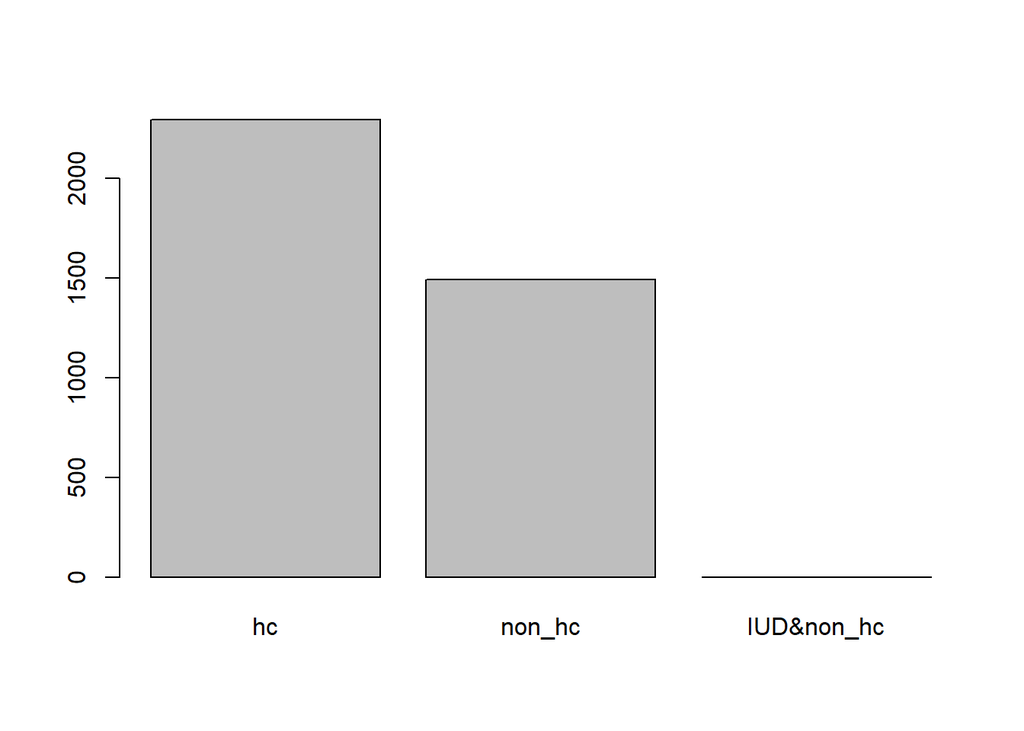

```r
plot(cccu_MA$hc)
```

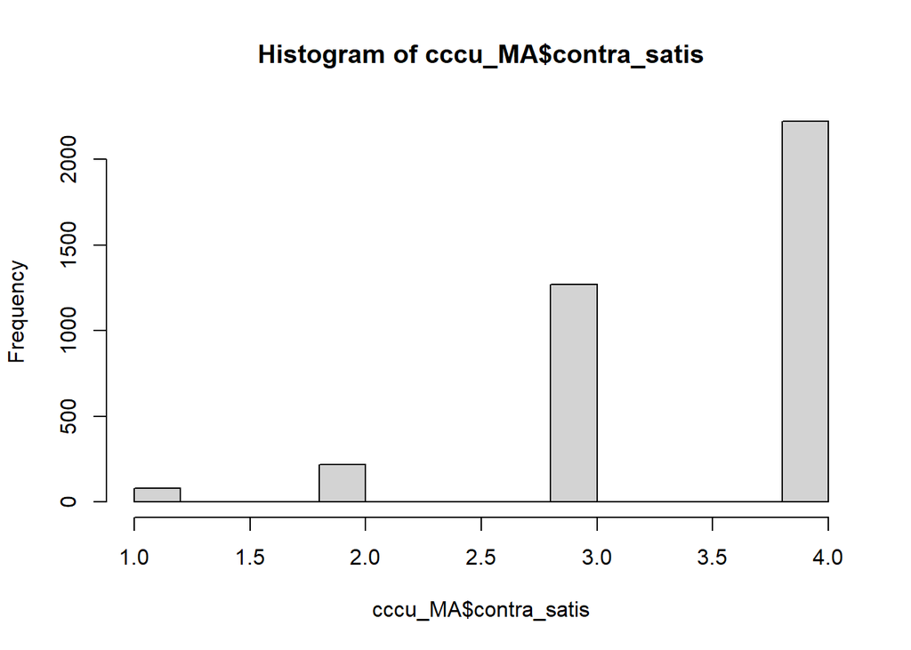

```r
#contraceptive satisfaction
hist(cccu_MA$contra_satis) #no normal distribution
```

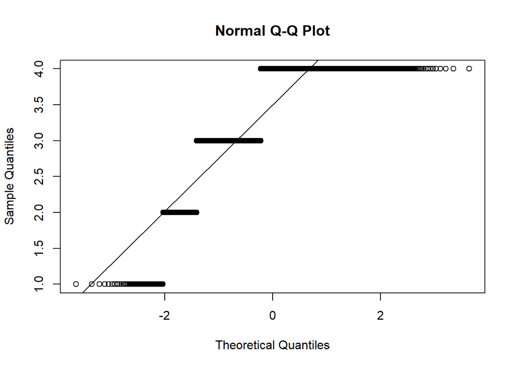

```r
qqnorm(cccu_MA$contra_satis)
qqline(cccu_MA$contra_satis)
```

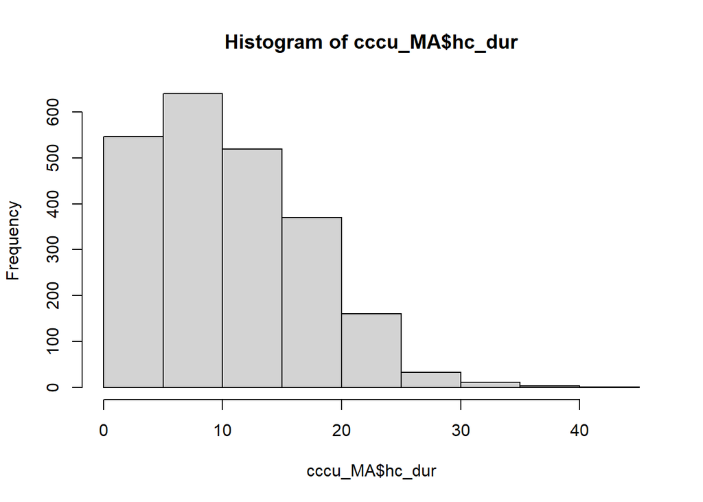

```r
#contraceptive duration
hist(cccu_MA$hc_dur) #no normal distribution
```

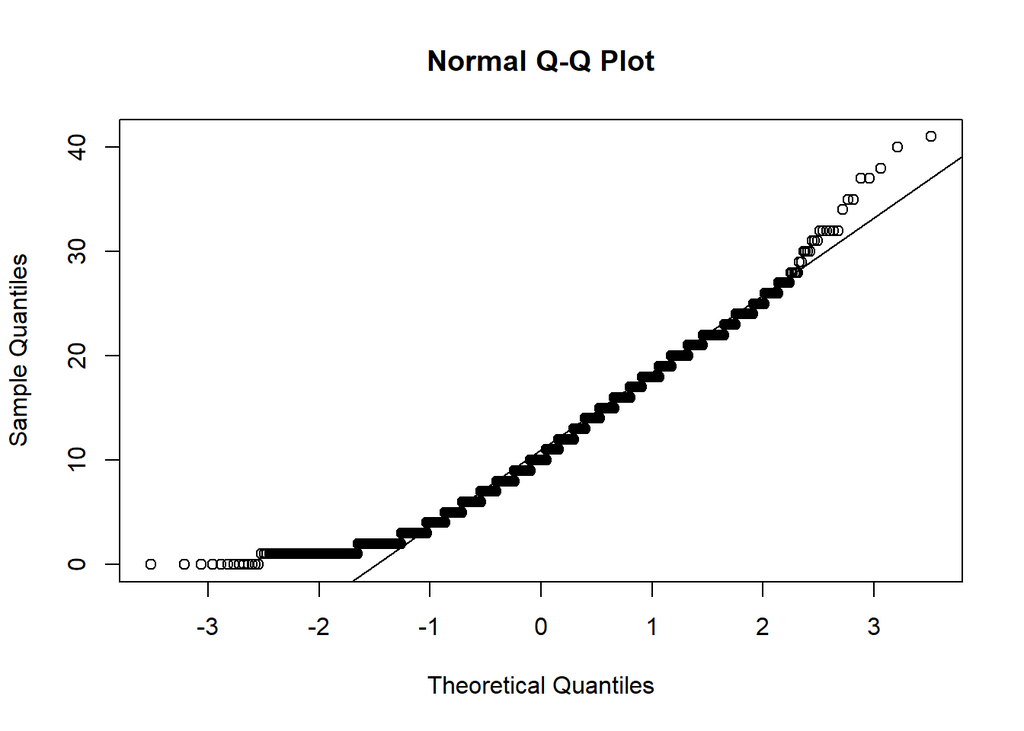

```r
qqnorm(cccu_MA$hc_dur)
qqline(cccu_MA$hc_dur)
```

```r
table(cccu_MA$hc_dur)
```

```
##
##   0   1   2   3   4   5   6   7   8   9  10  11  12  13  14  15  16  17  18  19
##  13 100 124 109  97 103 127 113 140 132 127 101 120  90 106 102  98  69  87  52
##  20  21  22  23  24  25  26  27  28  29  30  31  32  34  35  37  38  40  41
##  64  46  53  22  26  14  13   9   5   2   4   3   6   1   2   2   1   1   1
```

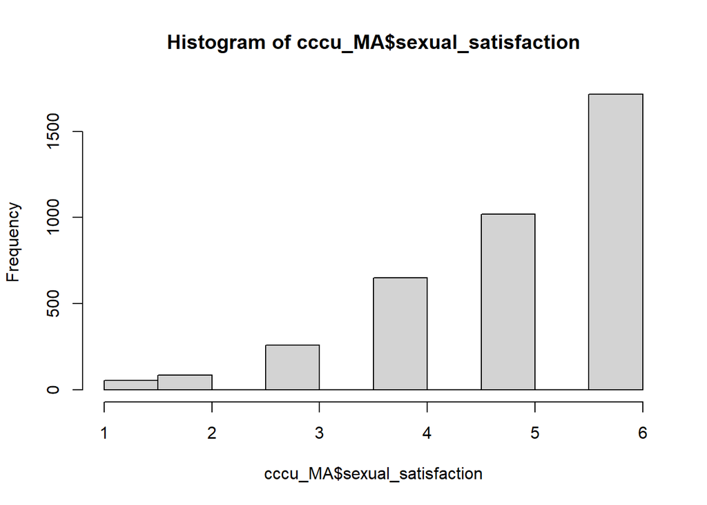

```r
#sexual satisfaction
hist(cccu_MA$sexual_satisfaction) #no normal distribution
```

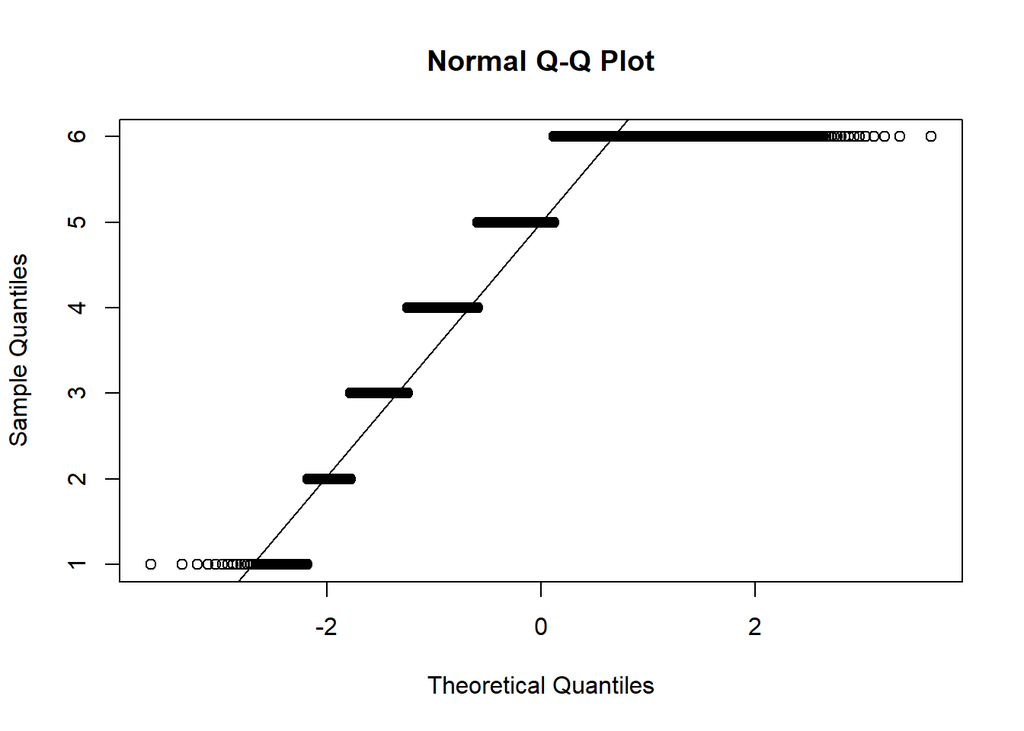

```r
qqnorm(cccu_MA$sexual_satisfaction)
qqline(cccu_MA$sexual_satisfaction)
```

```r
#sexual frequency
table(cccu_MA$sex_freq)
```

```
##
##   No sex or once        2-5 times       6-10 times 11 or more times
##              498             1659             1036              594
```

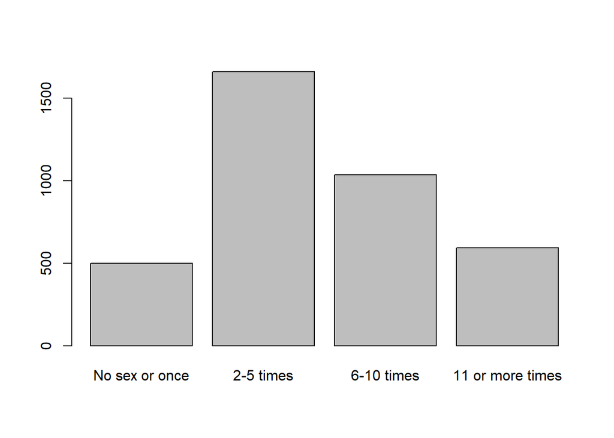

```r
plot(cccu_MA$sex_freq)#no sex und once relativ klein
```

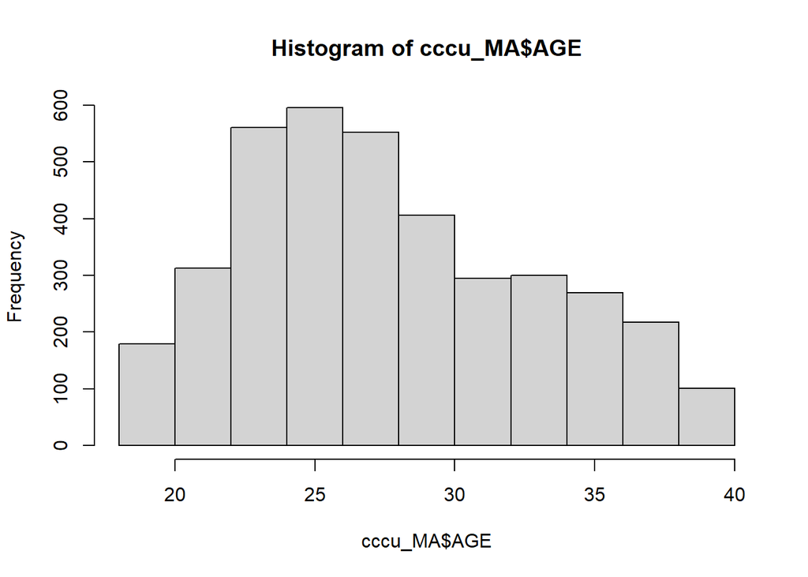

```r
#Age
hist(cccu_MA$AGE) #nearly no normal distribution
```

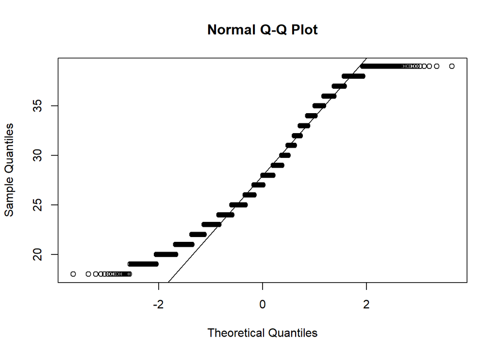

```r
qqnorm(cccu_MA$AGE)
qqline(cccu_MA$AGE)
```

```r
#degree
table(cccu_MA$DEGREE_recode)#no education bis 12. klasse sehr klein, ebenso doctoral degree
```

```
##
##               no formal education                  1st to 4th grade
##                                 0                                 1
##                     5th/6th grade                     7th/8th grade
##                                19                                15
##                         9th grade                        10th grade
##                                20                                26
##                        11th grade           12th grade / no diploma
##                                21                                27
## high school diploma or equivalent           some college, no degree
##                               421                               924
##                  associate degree                  bachelors degree
##                               402                              1364
##                    masters degree   professional or doctoral degree
##                               442                               105
```

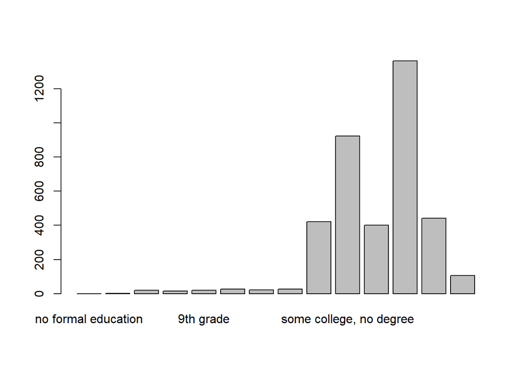

```r
plot(cccu_MA$DEGREE_recode)
```

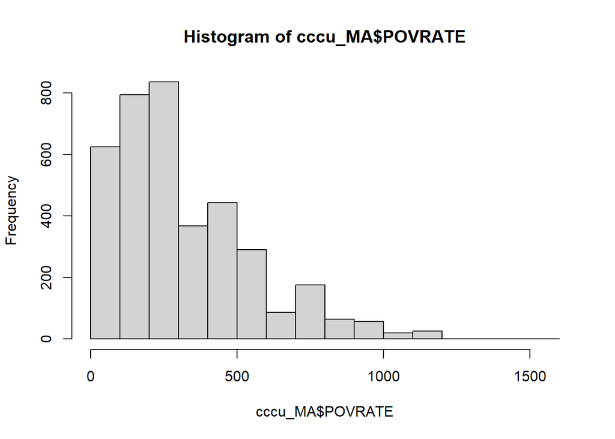

```r
#Povrate
hist(cccu_MA$POVRATE) #no normal distribution
```

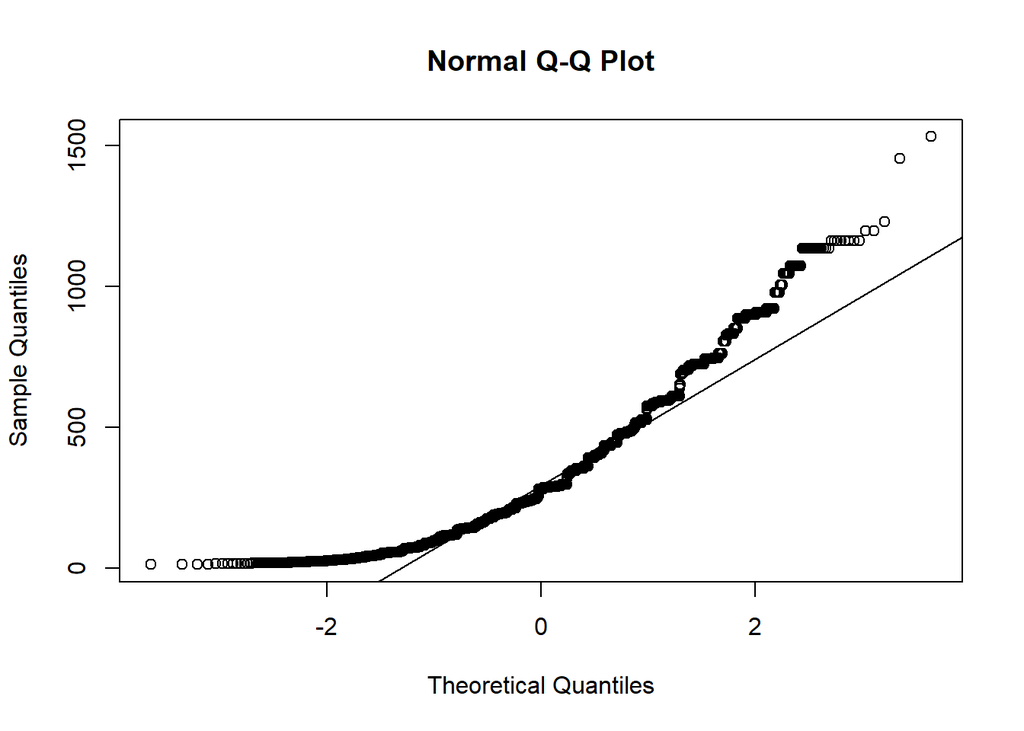

```r
qqnorm(cccu_MA$POVRATE)
qqline(cccu_MA$POVRATE)
```

```r
#health problems
table(cccu_MA$HLTHPROB_recode)#yes klein
```

```
##
##   No  Yes
## 3125  662
```

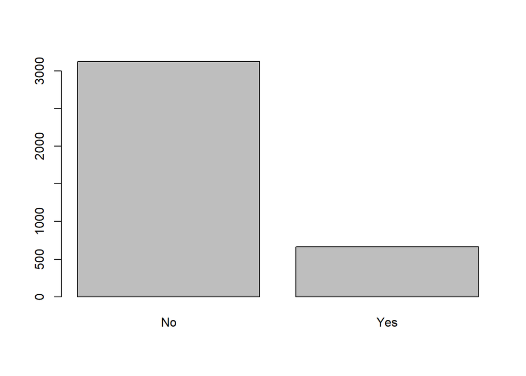

```r
plot(cccu_MA$HLTHPROB_recode)
```

```r
#medical problems
table(cccu_MA$MEDPROB_recode)#yes klein
```

```
##
##   No  Yes
## 3444  343
```

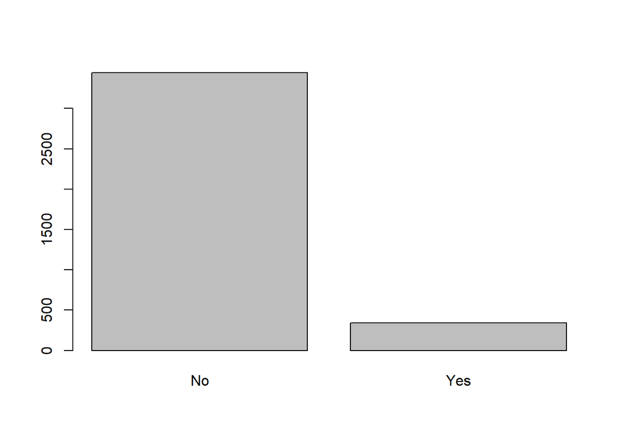

```r
plot(cccu_MA$MEDPROB_recode)
```

```r
#gaps in insurance
table(cccu_MA$GAPINS_recode)#yes klein
```

```
##
##   No  Yes
## 3076  711
```

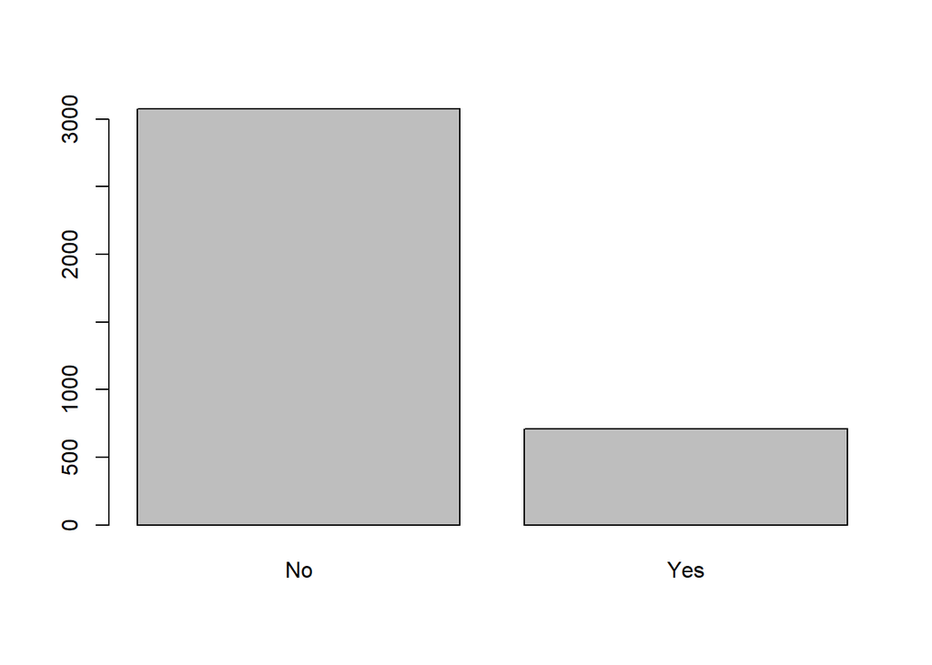

```r
plot(cccu_MA$GAPINS_recode)
```

```r
#insuranced
table(cccu_MA$TYPEINS_recode)#no klein
```

```
##
##   No  Yes
##  569 3218
```

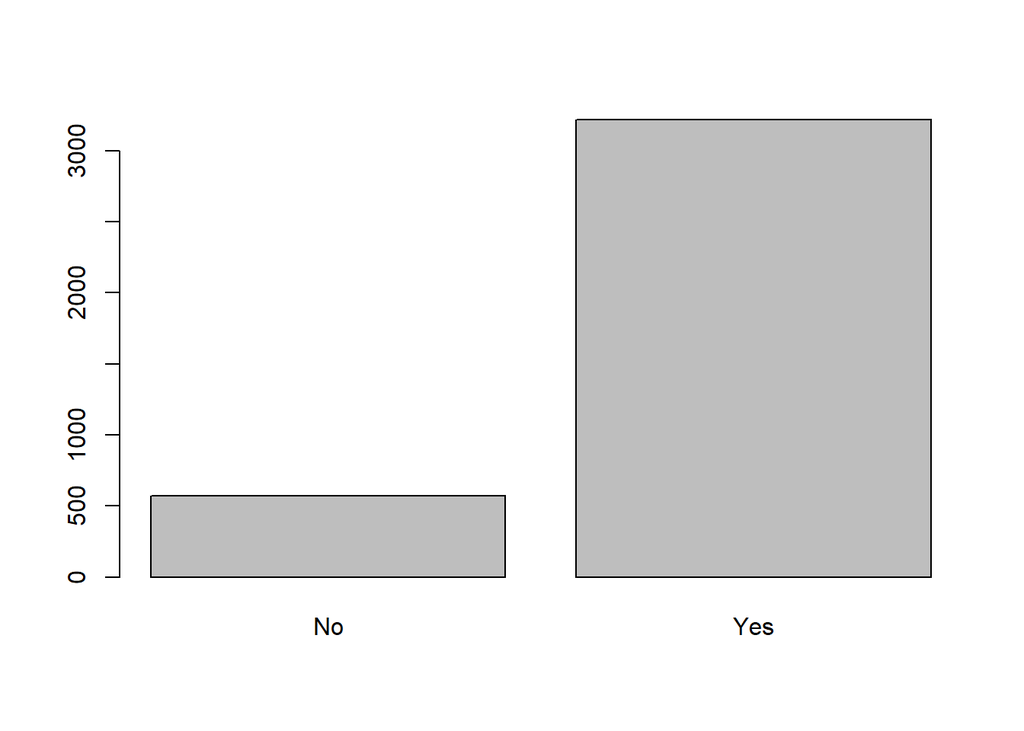

```r
plot(cccu_MA$TYPEINS_recode)
```

```r
#nkids t1
table(cccu_MA$NKIDS_t1)# 3 und 4 oder mehr Kinder klein
```

```
##
##         0         1         2         3 4 or more
##      2121       704       631       216       115
```

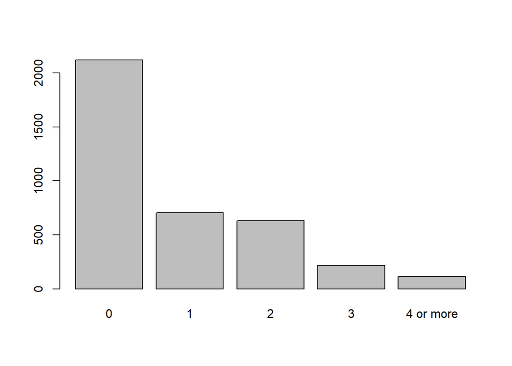

```r
plot(cccu_MA$NKIDS_t1)
```

```r
#pregnant / had baby between waves
table(cccu_MA$pregnant_between_waves)#yes klein
```

```
##
##   No  Yes
## 3655  132
```

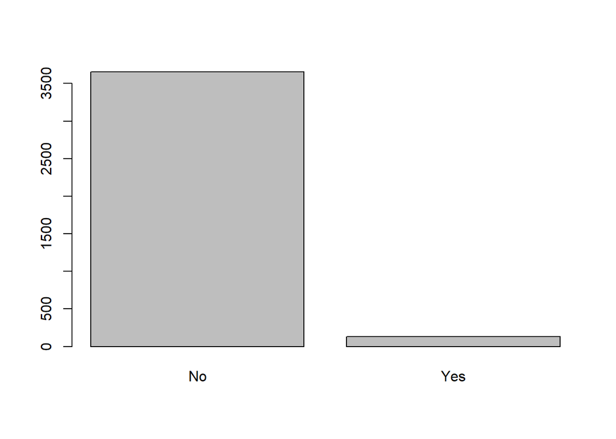

```r
plot(cccu_MA$pregnant_between_waves)
```

```r
table(cccu_MA$had_baby_between_waves)#yes klein
```

```
##
##   No  Yes
## 3697   90
```

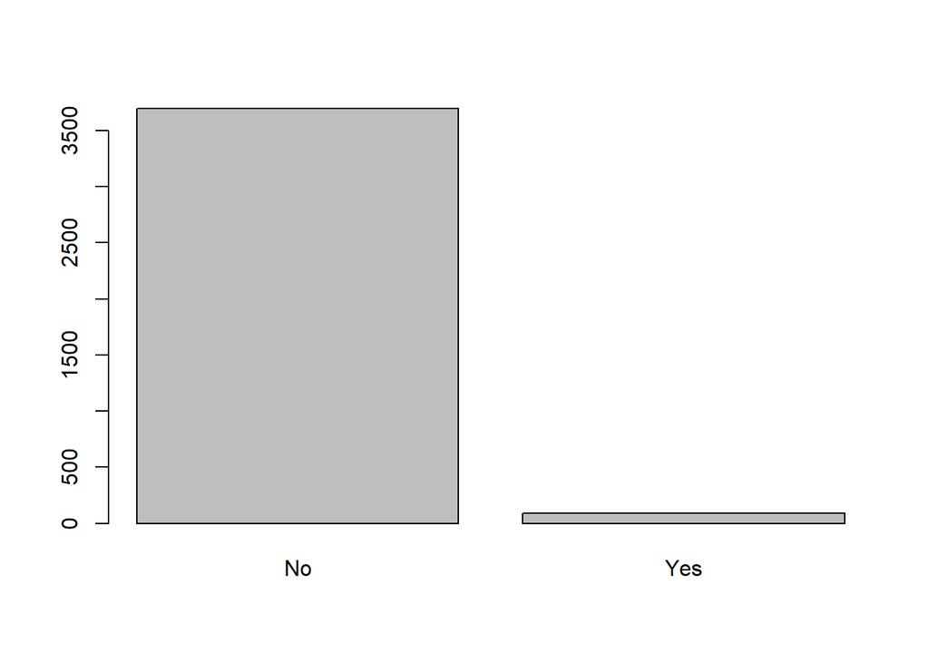

```r
plot(cccu_MA$had_baby_between_waves)
```

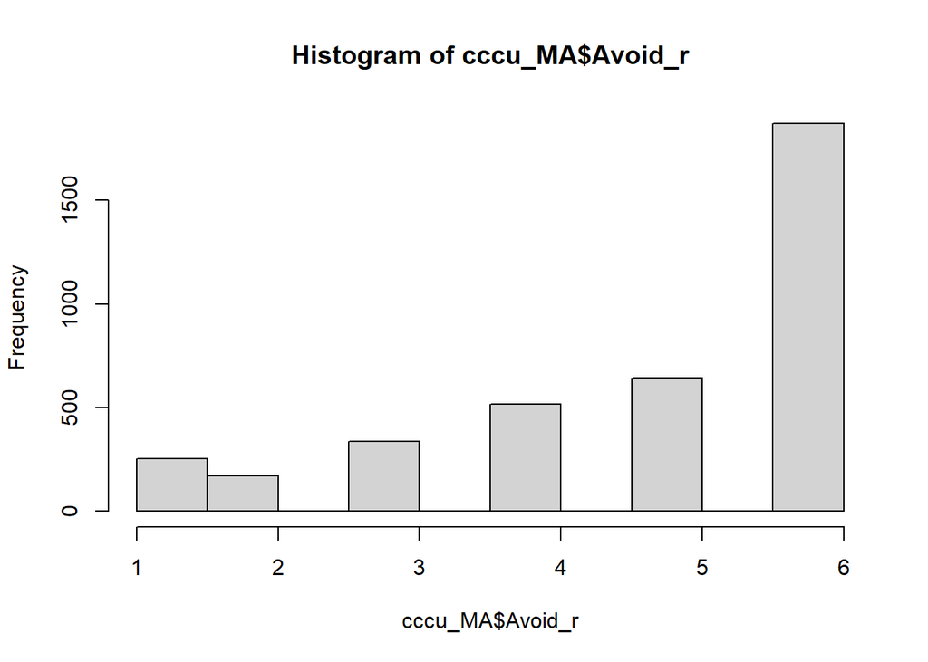

```r
#avoidance
hist(cccu_MA$Avoid_r) #no normal distribution
```

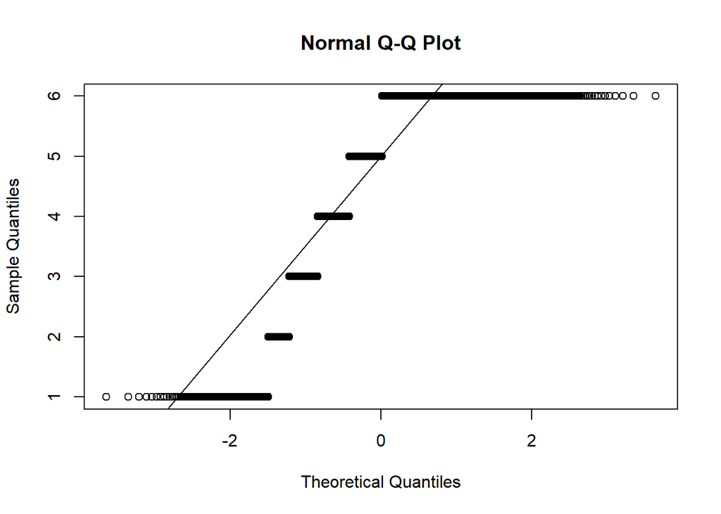

```r
qqnorm(cccu_MA$Avoid_r)
qqline(cccu_MA$Avoid_r)
```

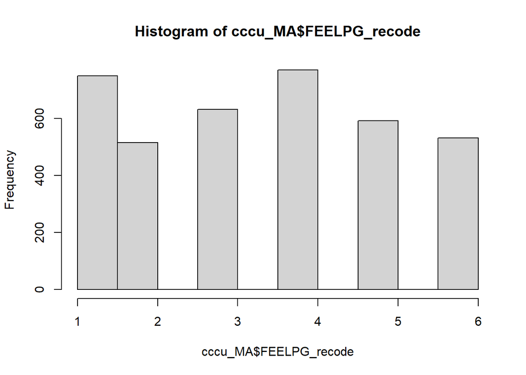

```r
#feelings about pregnancy
hist(cccu_MA$FEELPG_recode) #no normal distribution
```

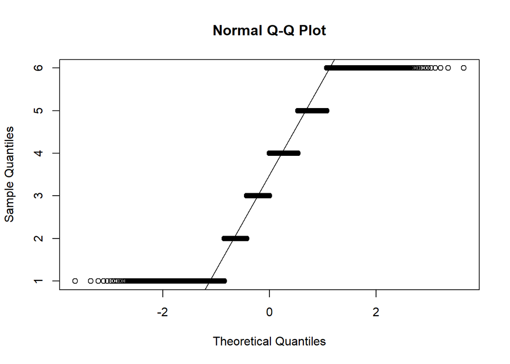

```r
qqnorm(cccu_MA$FEELPG_recode)
qqline(cccu_MA$FEELPG_recode)
```

```r
#relationship duration
table(cccu_MA$rel_dur_factor)
```

```
##
##   Single   0q-25q  26q-50q  51q-75q 76q-100q
##      932      792      760      684      619
```

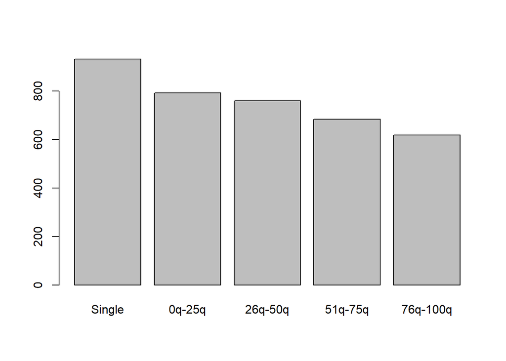

```r
plot(cccu_MA$rel_dur_factor)
```